# Project: FBI Gun Data Analysis

- Introduction
- Data Wrangling
- Exploratory Data Analysis
- Conclusions

## Introduction

> This analysis will explore relationships/trends between the 2016 Census and FBI Gun Data.
> - **Questions to be explored**:
>   - Which factors are most correlated with gun registration in 2016?
>   - Which states Per Capita had the most guns registered in 2016?
>   - Which state has seen the most growth in gun registration in the last decade?

For this analysis I will be using pandas_bokeh and bokeh plotting for my visualizations for two reasons:

- **To explore options outside the normal scope of Udacity projects**
- **Make the graph's interactive for the end user**

The cell below is used to install bokeh in the Jupyter Notebook

```python
! pip install pandas_bokeh
```

```python
import pandas as pd
import pandas_bokeh as pdb
import numpy as np
import matplotlib.pyplot as plt
import seaborn as sns
from bokeh.plotting import figure, output_notebook, show
from bokeh.models.tools import HoverTool
from bokeh.models import ColumnDataSource

%config IPCompleter.greedy = True
```

## Data Wrangling

### General Properties

Below I loaded the data files from a csv and excel format into their respective dataframes and utilize methods to determine what the data looks like in its raw form.

### Methods Used:

- **df.head():** to determine if the csv/excel files pulled in correctly and did not have another delimiter
- **df.shape():** to explore the number of columns and rows in the data
- **df.info():** to explore data types and missing values
- **df.describe():** To explore summary stats
- **df.isnull:** to explore null values and determine how I want to fill or drop them

```python
df_census = pd.read_csv('U.S. Census Data.csv')

df_guns = pd.read_excel('gun_data.xlsx')
```

```python
display(df_census.head())
df_guns.head()
```

|  | Fact | Fact Note | Alabama | Alaska | Arizona | Arkansas | California | Colorado | Connecticut | Delaware | ... | South Dakota | Tennessee | Texas | Utah | Vermont | Virginia | Washington | West Virginia | Wisconsin | Wyoming |
| --- | --- | --- | --- | --- | --- | --- | --- | --- | --- | --- | --- | --- | --- | --- | --- | --- | --- | --- | --- | --- | --- |
| 0 | Population estimates, July 1, 2016, (V2016) | NaN | 4,863,300 | 741,894 | 6,931,071 | 2,988,248 | 39,250,017 | 5,540,545 | 3,576,452 | 952,065 | ... | 865454 | 6651194 | 27,862,596 | 3,051,217 | 624,594 | 8,411,808 | 7,288,000 | 1,831,102 | 5,778,708 | 585,501 |
| 1 | Population estimates base, April 1, 2010, (V2... | NaN | 4,780,131 | 710,249 | 6,392,301 | 2,916,025 | 37,254,522 | 5,029,324 | 3,574,114 | 897,936 | ... | 814195 | 6346298 | 25,146,100 | 2,763,888 | 625,741 | 8,001,041 | 6,724,545 | 1,853,011 | 5,687,289 | 563,767 |
| 2 | Population, percent change - April 1, 2010 (es... | NaN | 1.70% | 4.50% | 8.40% | 2.50% | 5.40% | 10.20% | 0.10% | 6.00% | ... | 0.063 | 0.048 | 10.80% | 10.40% | -0.20% | 5.10% | 8.40% | -1.20% | 1.60% | 3.90% |
| 3 | Population, Census, April 1, 2010 | NaN | 4,779,736 | 710,231 | 6,392,017 | 2,915,918 | 37,253,956 | 5,029,196 | 3,574,097 | 897,934 | ... | 814180 | 6346105 | 25,145,561 | 2,763,885 | 625,741 | 8,001,024 | 6,724,540 | 1,852,994 | 5,686,986 | 563,626 |
| 4 | Persons under 5 years, percent, July 1, 2016, ... | NaN | 6.00% | 7.30% | 6.30% | 6.40% | 6.30% | 6.10% | 5.20% | 5.80% | ... | 0.071 | 0.061 | 7.20% | 8.30% | 4.90% | 6.10% | 6.20% | 5.50% | 5.80% | 6.50% |

5 rows × 52 columns

|  | month | state | permit | permit_recheck | handgun | long_gun | other | multiple | admin | prepawn_handgun | ... | returned_other | rentals_handgun | rentals_long_gun | private_sale_handgun | private_sale_long_gun | private_sale_other | return_to_seller_handgun | return_to_seller_long_gun | return_to_seller_other | totals |
| --- | --- | --- | --- | --- | --- | --- | --- | --- | --- | --- | --- | --- | --- | --- | --- | --- | --- | --- | --- | --- | --- |
| 0 | 2017-09 | Alabama | 16717.0 | 0.0 | 5734.0 | 6320.0 | 221.0 | 317 | 0.0 | 15.0 | ... | 0.0 | 0.0 | 0.0 | 9.0 | 16.0 | 3.0 | 0.0 | 0.0 | 3.0 | 32019 |
| 1 | 2017-09 | Alaska | 209.0 | 2.0 | 2320.0 | 2930.0 | 219.0 | 160 | 0.0 | 5.0 | ... | 0.0 | 0.0 | 0.0 | 17.0 | 24.0 | 1.0 | 0.0 | 0.0 | 0.0 | 6303 |
| 2 | 2017-09 | Arizona | 5069.0 | 382.0 | 11063.0 | 7946.0 | 920.0 | 631 | 0.0 | 13.0 | ... | 0.0 | 0.0 | 0.0 | 38.0 | 12.0 | 2.0 | 0.0 | 0.0 | 0.0 | 28394 |
| 3 | 2017-09 | Arkansas | 2935.0 | 632.0 | 4347.0 | 6063.0 | 165.0 | 366 | 51.0 | 12.0 | ... | 0.0 | 0.0 | 0.0 | 13.0 | 23.0 | 0.0 | 0.0 | 2.0 | 1.0 | 17747 |
| 4 | 2017-09 | California | 57839.0 | 0.0 | 37165.0 | 24581.0 | 2984.0 | 0 | 0.0 | 0.0 | ... | 0.0 | 0.0 | 0.0 | 0.0 | 0.0 | 0.0 | 0.0 | 0.0 | 0.0 | 123506 |

5 rows × 27 columns

```python
display(df_census.shape)

df_guns.shape
```

```
(85, 52)
```

```
(12485, 27)
```

### Census Data Cleaning

> Now that I see the data has successfully loaded, there are steps I want to take to clean the census data which include:
- Handling Nulls
- Transposing the data
- Dropping Columns
- Changing the Data Types

### Handling Nulls

When running `df_census.info()` I see most of the null values stem from rows tags in the **Fact** column that aren't needed for this analysis. These rows will be dropped

```python
df_census.info()
```

```
<class 'pandas.core.frame.DataFrame'>
RangeIndex: 85 entries, 0 to 84
Data columns (total 52 columns):
Fact              80 non-null object
Fact Note         28 non-null object
Alabama           65 non-null object
Alaska            65 non-null object
Arizona           65 non-null object
Arkansas          65 non-null object
California        65 non-null object
Colorado          65 non-null object
Connecticut       65 non-null object
Delaware          65 non-null object
Florida           65 non-null object
Georgia           65 non-null object
Hawaii            65 non-null object
Idaho             65 non-null object
Illinois          65 non-null object
Indiana           65 non-null object
Iowa              65 non-null object
Kansas            65 non-null object
Kentucky          65 non-null object
Louisiana         65 non-null object
Maine             65 non-null object
Maryland          65 non-null object
Massachusetts     65 non-null object
Michigan          65 non-null object
Minnesota         65 non-null object
Mississippi       65 non-null object
Missouri          65 non-null object
Montana           65 non-null object
Nebraska          65 non-null object
Nevada            65 non-null object
New Hampshire     65 non-null object
New Jersey        65 non-null object
New Mexico        65 non-null object
New York          65 non-null object
North Carolina    65 non-null object
North Dakota      65 non-null object
Ohio              65 non-null object
Oklahoma          65 non-null object
Oregon            65 non-null object
Pennsylvania      65 non-null object
Rhode Island      65 non-null object
South Carolina    65 non-null object
South Dakota      65 non-null object
Tennessee         65 non-null object
Texas             65 non-null object
Utah              65 non-null object
Vermont           65 non-null object
Virginia          65 non-null object
Washington        65 non-null object
West Virginia     65 non-null object
Wisconsin         65 non-null object
Wyoming           65 non-null object
dtypes: object(52)
memory usage: 34.6+ KB
```

```python
df_census[df_census.Alabama.isnull()]
```

|  | Fact | Fact Note | Alabama | Alaska | Arizona | Arkansas | California | Colorado | Connecticut | Delaware | ... | South Dakota | Tennessee | Texas | Utah | Vermont | Virginia | Washington | West Virginia | Wisconsin | Wyoming |
| --- | --- | --- | --- | --- | --- | --- | --- | --- | --- | --- | --- | --- | --- | --- | --- | --- | --- | --- | --- | --- | --- |
| 65 | NaN | NaN | NaN | NaN | NaN | NaN | NaN | NaN | NaN | NaN | ... | NaN | NaN | NaN | NaN | NaN | NaN | NaN | NaN | NaN | NaN |
| 66 | NOTE: FIPS Code values are enclosed in quotes ... | NaN | NaN | NaN | NaN | NaN | NaN | NaN | NaN | NaN | ... | NaN | NaN | NaN | NaN | NaN | NaN | NaN | NaN | NaN | NaN |
| 67 | NaN | NaN | NaN | NaN | NaN | NaN | NaN | NaN | NaN | NaN | ... | NaN | NaN | NaN | NaN | NaN | NaN | NaN | NaN | NaN | NaN |
| 68 | Value Notes | NaN | NaN | NaN | NaN | NaN | NaN | NaN | NaN | NaN | ... | NaN | NaN | NaN | NaN | NaN | NaN | NaN | NaN | NaN | NaN |
| 69 | 1 | Includes data not distributed by county. | NaN | NaN | NaN | NaN | NaN | NaN | NaN | NaN | ... | NaN | NaN | NaN | NaN | NaN | NaN | NaN | NaN | NaN | NaN |
| 70 | NaN | NaN | NaN | NaN | NaN | NaN | NaN | NaN | NaN | NaN | ... | NaN | NaN | NaN | NaN | NaN | NaN | NaN | NaN | NaN | NaN |
| 71 | Fact Notes | NaN | NaN | NaN | NaN | NaN | NaN | NaN | NaN | NaN | ... | NaN | NaN | NaN | NaN | NaN | NaN | NaN | NaN | NaN | NaN |
| 72 | (a) | Includes persons reporting only one race | NaN | NaN | NaN | NaN | NaN | NaN | NaN | NaN | ... | NaN | NaN | NaN | NaN | NaN | NaN | NaN | NaN | NaN | NaN |
| 73 | (b) | Hispanics may be of any race, so also are incl... | NaN | NaN | NaN | NaN | NaN | NaN | NaN | NaN | ... | NaN | NaN | NaN | NaN | NaN | NaN | NaN | NaN | NaN | NaN |
| 74 | (c) | Economic Census - Puerto Rico data are not com... | NaN | NaN | NaN | NaN | NaN | NaN | NaN | NaN | ... | NaN | NaN | NaN | NaN | NaN | NaN | NaN | NaN | NaN | NaN |
| 75 | NaN | NaN | NaN | NaN | NaN | NaN | NaN | NaN | NaN | NaN | ... | NaN | NaN | NaN | NaN | NaN | NaN | NaN | NaN | NaN | NaN |
| 76 | Value Flags | NaN | NaN | NaN | NaN | NaN | NaN | NaN | NaN | NaN | ... | NaN | NaN | NaN | NaN | NaN | NaN | NaN | NaN | NaN | NaN |
| 77 | - | Either no or too few sample observations were ... | NaN | NaN | NaN | NaN | NaN | NaN | NaN | NaN | ... | NaN | NaN | NaN | NaN | NaN | NaN | NaN | NaN | NaN | NaN |
| 78 | D | Suppressed to avoid disclosure of confidential... | NaN | NaN | NaN | NaN | NaN | NaN | NaN | NaN | ... | NaN | NaN | NaN | NaN | NaN | NaN | NaN | NaN | NaN | NaN |
| 79 | F | Fewer than 25 firms | NaN | NaN | NaN | NaN | NaN | NaN | NaN | NaN | ... | NaN | NaN | NaN | NaN | NaN | NaN | NaN | NaN | NaN | NaN |
| 80 | FN | Footnote on this item in place of data | NaN | NaN | NaN | NaN | NaN | NaN | NaN | NaN | ... | NaN | NaN | NaN | NaN | NaN | NaN | NaN | NaN | NaN | NaN |
| 81 | NaN | Not available | NaN | NaN | NaN | NaN | NaN | NaN | NaN | NaN | ... | NaN | NaN | NaN | NaN | NaN | NaN | NaN | NaN | NaN | NaN |
| 82 | S | Suppressed; does not meet publication standards | NaN | NaN | NaN | NaN | NaN | NaN | NaN | NaN | ... | NaN | NaN | NaN | NaN | NaN | NaN | NaN | NaN | NaN | NaN |
| 83 | X | Not applicable | NaN | NaN | NaN | NaN | NaN | NaN | NaN | NaN | ... | NaN | NaN | NaN | NaN | NaN | NaN | NaN | NaN | NaN | NaN |
| 84 | Z | Value greater than zero but less than half uni... | NaN | NaN | NaN | NaN | NaN | NaN | NaN | NaN | ... | NaN | NaN | NaN | NaN | NaN | NaN | NaN | NaN | NaN | NaN |

20 rows × 52 columns

```python
drop_cen = df_census[df_census.Fact.notnull() & df_census.Alabama.isnull()].index

drop_cen
```

```
Int64Index([66, 68, 69, 71, 72, 73, 74, 76, 77, 78, 79, 80, 82, 83, 84], dtype='int64')
```

```python
df_census.drop(index = drop_cen, inplace = True)
df_census.info()
```

```
<class 'pandas.core.frame.DataFrame'>
Int64Index: 70 entries, 0 to 81
Data columns (total 52 columns):
Fact              65 non-null object
Fact Note         17 non-null object
Alabama           65 non-null object
Alaska            65 non-null object
Arizona           65 non-null object
Arkansas          65 non-null object
California        65 non-null object
Colorado          65 non-null object
Connecticut       65 non-null object
Delaware          65 non-null object
Florida           65 non-null object
Georgia           65 non-null object
Hawaii            65 non-null object
Idaho             65 non-null object
Illinois          65 non-null object
Indiana           65 non-null object
Iowa              65 non-null object
Kansas            65 non-null object
Kentucky          65 non-null object
Louisiana         65 non-null object
Maine             65 non-null object
Maryland          65 non-null object
Massachusetts     65 non-null object
Michigan          65 non-null object
Minnesota         65 non-null object
Mississippi       65 non-null object
Missouri          65 non-null object
Montana           65 non-null object
Nebraska          65 non-null object
Nevada            65 non-null object
New Hampshire     65 non-null object
New Jersey        65 non-null object
New Mexico        65 non-null object
New York          65 non-null object
North Carolina    65 non-null object
North Dakota      65 non-null object
Ohio              65 non-null object
Oklahoma          65 non-null object
Oregon            65 non-null object
Pennsylvania      65 non-null object
Rhode Island      65 non-null object
South Carolina    65 non-null object
South Dakota      65 non-null object
Tennessee         65 non-null object
Texas             65 non-null object
Utah              65 non-null object
Vermont           65 non-null object
Virginia          65 non-null object
Washington        65 non-null object
West Virginia     65 non-null object
Wisconsin         65 non-null object
Wyoming           65 non-null object
dtypes: object(52)
memory usage: 29.0+ KB
```

### Transposing Data

I noticed that in the Census data all the demographics were under the "Fact" column and all the states have their own column. I want to change this so the demographics are their own separate columns and the states are the rows

```python
pd.set_option('max_columns', None )
pd.set_option('max_colwidth', 100)
df_census = df_census.transpose()

df_census.head()
```

|  | 0 | 1 | 2 | 3 | 4 | 5 | 6 | 7 | 8 | 9 | 10 | 11 | 12 | 13 | 14 | 15 | 16 | 17 | 18 | 19 | 20 | 21 | 22 | 23 | 24 | 25 | 26 | 27 | 28 | … |
| --- | --- | --- | --- | --- | --- | --- | --- | --- | --- | --- | --- | --- | --- | --- | --- | --- | --- | --- | --- | --- | --- | --- | --- | --- | --- | --- | --- | --- | --- | --- |
| Fact | Population estimates, July 1, 2016, (V2016) | Population estimates base, April 1, 2010, (V2016) | Population, percent change - April 1, 2010 (estimates base) to July 1, 2016, (V2016) | Population, Census, April 1, 2010 | Persons under 5 years, percent, July 1, 2016, (V2016) | Persons under 5 years, percent, April 1, 2010 | Persons under 18 years, percent, July 1, 2016, (V2016) | Persons under 18 years, percent, April 1, 2010 | Persons 65 years and over, percent, July 1, 2016, (V2016) | Persons 65 years and over, percent, April 1, 2010 | Female persons, percent, July 1, 2016, (V2016) | Female persons, percent, April 1, 2010 | White alone, percent, July 1, 2016, (V2016) | Black or African American alone, percent, July 1, 2016, (V2016) | American Indian and Alaska Native alone, percent, July 1, 2016, (V2016) | Asian alone, percent, July 1, 2016, (V2016) | Native Hawaiian and Other Pacific Islander alone, percent, July 1, 2016, (V2016) | Two or More Races, percent, July 1, 2016, (V2016) | Hispanic or Latino, percent, July 1, 2016, (V2016) | White alone, not Hispanic or Latino, percent, July 1, 2016, (V2016) | Veterans, 2011-2015 | Foreign born persons, percent, 2011-2015 | Housing units, July 1, 2016, (V2016) | Housing units, April 1, 2010 | Owner-occupied housing unit rate, 2011-2015 | Median value of owner-occupied housing units, 2011-2015 | Median selected monthly owner costs -with a mortgage, 2011-2015 | Median selected monthly owner costs -without a mortgage, 2011-2015 | Median gross rent, 2011-2015 | … |
| Fact Note | NaN | NaN | NaN | NaN | NaN | NaN | NaN | NaN | NaN | NaN | NaN | NaN | (a) | (a) | (a) | (a) | (a) | NaN | (b) | NaN | NaN | NaN | NaN | NaN | NaN | NaN | NaN | NaN | NaN | … |
| Alabama | 4,863,300 | 4,780,131 | 1.70% | 4,779,736 | 6.00% | 6.40% | 22.60% | 23.70% | 16.10% | 13.80% | 51.60% | 51.50% | 69.30% | 26.80% | 0.70% | 1.40% | 0.10% | 1.60% | 4.20% | 65.80% | 363,170 | 3.50% | 2,230,185 | 2,171,853 | 68.70% | $125,500 | $1,139 | $345 | $717 | … |
| Alaska | 741,894 | 710,249 | 4.50% | 710,231 | 7.30% | 7.60% | 25.20% | 26.40% | 10.40% | 7.70% | 47.70% | 48.00% | 66.10% | 3.80% | 15.20% | 6.30% | 1.30% | 7.30% | 7.00% | 61.20% | 69,323 | 7.40% | 310,658 | 306,967 | 63.40% | $250,000 | $1,827 | $554 | $1,146 | … |
| Arizona | 6,931,071 | 6,392,301 | 8.40% | 6,392,017 | 6.30% | 7.10% | 23.50% | 25.50% | 16.90% | 13.80% | 50.30% | 50.30% | 83.30% | 4.90% | 5.40% | 3.40% | 0.30% | 2.80% | 30.90% | 55.50% | 505,794 | 13.50% | 2,961,003 | 2,844,526 | 62.80% | $167,500 | $1,343 | $380 | $913 | … |

### Transposing Data Continued

I now have my Census data in the row and column format that I prefer to see, but I also want the first row to be the column headers

```python
df_census.columns = df_census.iloc[0]
df_census.drop(index = 'Fact', inplace = True)

df_census.head()
```

| Fact | Population estimates, July 1, 2016, (V2016) | Population estimates base, April 1, 2010, (V2016) | Population, percent change - April 1, 2010 (estimates base) to July 1, 2016, (V2016) | Population, Census, April 1, 2010 | Persons under 5 years, percent, July 1, 2016, (V2016) | Persons under 5 years, percent, April 1, 2010 | Persons under 18 years, percent, July 1, 2016, (V2016) | Persons under 18 years, percent, April 1, 2010 | Persons 65 years and over, percent, July 1, 2016, (V2016) | Persons 65 years and over, percent, April 1, 2010 | Female persons, percent, July 1, 2016, (V2016) | Female persons, percent, April 1, 2010 | White alone, percent, July 1, 2016, (V2016) | Black or African American alone, percent, July 1, 2016, (V2016) | American Indian and Alaska Native alone, percent, July 1, 2016, (V2016) | Asian alone, percent, July 1, 2016, (V2016) | Native Hawaiian and Other Pacific Islander alone, percent, July 1, 2016, (V2016) | Two or More Races, percent, July 1, 2016, (V2016) | Hispanic or Latino, percent, July 1, 2016, (V2016) | White alone, not Hispanic or Latino, percent, July 1, 2016, (V2016) | Veterans, 2011-2015 | Foreign born persons, percent, 2011-2015 | Housing units, July 1, 2016, (V2016) | Housing units, April 1, 2010 | Owner-occupied housing unit rate, 2011-2015 | Median value of owner-occupied housing units, 2011-2015 | Median selected monthly owner costs -with a mortgage, 2011-2015 | Median selected monthly owner costs -without a mortgage, 2011-2015 | Median gross rent, 2011-2015 | … |
| --- | --- | --- | --- | --- | --- | --- | --- | --- | --- | --- | --- | --- | --- | --- | --- | --- | --- | --- | --- | --- | --- | --- | --- | --- | --- | --- | --- | --- | --- | --- |
| Fact Note | NaN | NaN | NaN | NaN | NaN | NaN | NaN | NaN | NaN | NaN | NaN | NaN | (a) | (a) | (a) | (a) | (a) | NaN | (b) | NaN | NaN | NaN | NaN | NaN | NaN | NaN | NaN | NaN | NaN | … |
| Alabama | 4,863,300 | 4,780,131 | 1.70% | 4,779,736 | 6.00% | 6.40% | 22.60% | 23.70% | 16.10% | 13.80% | 51.60% | 51.50% | 69.30% | 26.80% | 0.70% | 1.40% | 0.10% | 1.60% | 4.20% | 65.80% | 363,170 | 3.50% | 2,230,185 | 2,171,853 | 68.70% | $125,500 | $1,139 | $345 | $717 | … |
| Alaska | 741,894 | 710,249 | 4.50% | 710,231 | 7.30% | 7.60% | 25.20% | 26.40% | 10.40% | 7.70% | 47.70% | 48.00% | 66.10% | 3.80% | 15.20% | 6.30% | 1.30% | 7.30% | 7.00% | 61.20% | 69,323 | 7.40% | 310,658 | 306,967 | 63.40% | $250,000 | $1,827 | $554 | $1,146 | … |
| Arizona | 6,931,071 | 6,392,301 | 8.40% | 6,392,017 | 6.30% | 7.10% | 23.50% | 25.50% | 16.90% | 13.80% | 50.30% | 50.30% | 83.30% | 4.90% | 5.40% | 3.40% | 0.30% | 2.80% | 30.90% | 55.50% | 505,794 | 13.50% | 2,961,003 | 2,844,526 | 62.80% | $167,500 | $1,343 | $380 | $913 | … |
| Arkansas | 2,988,248 | 2,916,025 | 2.50% | 2,915,918 | 6.40% | 6.80% | 23.60% | 24.40% | 16.30% | 14.40% | 50.90% | 50.90% | 79.40% | 15.70% | 1.00% | 1.60% | 0.30% | 2.00% | 7.30% | 72.90% | 220,953 | 4.70% | 1,354,762 | 1,316,299 | 66.10% | $111,400 | $1,019 | $327 | $677 | … |

### Dropping Columns

I have several columns with **nan** values that I want to remove, as well as dropping the **Fact Note** Column

```python
df_census.dropna(axis = 1, how = 'all', inplace = True)

df_census.drop(axis = 1, columns = [df_census.columns[-1]], inplace = True)
```

```python
df_census.drop(axis = 0, index = 'Fact Note', inplace = True)
```

```python
df_census.head()
```

| Fact | Population estimates, July 1, 2016, (V2016) | Population estimates base, April 1, 2010, (V2016) | Population, percent change - April 1, 2010 (estimates base) to July 1, 2016, (V2016) | Population, Census, April 1, 2010 | Persons under 5 years, percent, July 1, 2016, (V2016) | Persons under 5 years, percent, April 1, 2010 | Persons under 18 years, percent, July 1, 2016, (V2016) | Persons under 18 years, percent, April 1, 2010 | Persons 65 years and over, percent, July 1, 2016, (V2016) | Persons 65 years and over, percent, April 1, 2010 | Female persons, percent, July 1, 2016, (V2016) | Female persons, percent, April 1, 2010 | White alone, percent, July 1, 2016, (V2016) | Black or African American alone, percent, July 1, 2016, (V2016) | American Indian and Alaska Native alone, percent, July 1, 2016, (V2016) | Asian alone, percent, July 1, 2016, (V2016) | Native Hawaiian and Other Pacific Islander alone, percent, July 1, 2016, (V2016) | Two or More Races, percent, July 1, 2016, (V2016) | Hispanic or Latino, percent, July 1, 2016, (V2016) | White alone, not Hispanic or Latino, percent, July 1, 2016, (V2016) | Veterans, 2011-2015 | Foreign born persons, percent, 2011-2015 | Housing units, July 1, 2016, (V2016) | Housing units, April 1, 2010 | Owner-occupied housing unit rate, 2011-2015 | Median value of owner-occupied housing units, 2011-2015 | Median selected monthly owner costs -with a mortgage, 2011-2015 | Median selected monthly owner costs -without a mortgage, 2011-2015 | Median gross rent, 2011-2015 | … |
| --- | --- | --- | --- | --- | --- | --- | --- | --- | --- | --- | --- | --- | --- | --- | --- | --- | --- | --- | --- | --- | --- | --- | --- | --- | --- | --- | --- | --- | --- | --- |
| Alabama | 4,863,300 | 4,780,131 | 1.70% | 4,779,736 | 6.00% | 6.40% | 22.60% | 23.70% | 16.10% | 13.80% | 51.60% | 51.50% | 69.30% | 26.80% | 0.70% | 1.40% | 0.10% | 1.60% | 4.20% | 65.80% | 363,170 | 3.50% | 2,230,185 | 2,171,853 | 68.70% | $125,500 | $1,139 | $345 | $717 | … |
| Alaska | 741,894 | 710,249 | 4.50% | 710,231 | 7.30% | 7.60% | 25.20% | 26.40% | 10.40% | 7.70% | 47.70% | 48.00% | 66.10% | 3.80% | 15.20% | 6.30% | 1.30% | 7.30% | 7.00% | 61.20% | 69,323 | 7.40% | 310,658 | 306,967 | 63.40% | $250,000 | $1,827 | $554 | $1,146 | … |
| Arizona | 6,931,071 | 6,392,301 | 8.40% | 6,392,017 | 6.30% | 7.10% | 23.50% | 25.50% | 16.90% | 13.80% | 50.30% | 50.30% | 83.30% | 4.90% | 5.40% | 3.40% | 0.30% | 2.80% | 30.90% | 55.50% | 505,794 | 13.50% | 2,961,003 | 2,844,526 | 62.80% | $167,500 | $1,343 | $380 | $913 | … |
| Arkansas | 2,988,248 | 2,916,025 | 2.50% | 2,915,918 | 6.40% | 6.80% | 23.60% | 24.40% | 16.30% | 14.40% | 50.90% | 50.90% | 79.40% | 15.70% | 1.00% | 1.60% | 0.30% | 2.00% | 7.30% | 72.90% | 220,953 | 4.70% | 1,354,762 | 1,316,299 | 66.10% | $111,400 | $1,019 | $327 | $677 | … |
| California | 39,250,017 | 37,254,522 | 5.40% | 37,253,956 | 6.30% | 6.80% | 23.20% | 25.00% | 13.60% | 11.40% | 50.30% | 50.30% | 72.70% | 6.50% | 1.70% | 14.80% | 0.50% | 3.80% | 38.90% | 37.70% | 1,777,410 | 27.00% | 14,060,525 | 13,680,081 | 54.30% | $385,500 | $2,155 | $500 | $1,255 | … |

```python
df_census.info()
```

```
<class 'pandas.core.frame.DataFrame'>
Index: 50 entries, Alabama to Wyoming
Data columns (total 65 columns):
Population estimates, July 1, 2016,  (V2016)                                              50 non-null object
Population estimates base, April 1, 2010,  (V2016)                                        50 non-null object
Population, percent change - April 1, 2010 (estimates base) to July 1, 2016,  (V2016)     50 non-null object
Population, Census, April 1, 2010                                                         50 non-null object
Persons under 5 years, percent, July 1, 2016,  (V2016)                                    50 non-null object
Persons under 5 years, percent, April 1, 2010                                             50 non-null object
Persons under 18 years, percent, July 1, 2016,  (V2016)                                   50 non-null object
Persons under 18 years, percent, April 1, 2010                                            50 non-null object
Persons 65 years and over, percent,  July 1, 2016,  (V2016)                               50 non-null object
Persons 65 years and over, percent, April 1, 2010                                         50 non-null object
Female persons, percent,  July 1, 2016,  (V2016)                                          50 non-null object
Female persons, percent, April 1, 2010                                                    50 non-null object
White alone, percent, July 1, 2016,  (V2016)                                              50 non-null object
Black or African American alone, percent, July 1, 2016,  (V2016)                          50 non-null object
American Indian and Alaska Native alone, percent, July 1, 2016,  (V2016)                  50 non-null object
Asian alone, percent, July 1, 2016,  (V2016)                                              50 non-null object
Native Hawaiian and Other Pacific Islander alone, percent, July 1, 2016,  (V2016)         50 non-null object
Two or More Races, percent, July 1, 2016,  (V2016)                                        50 non-null object
Hispanic or Latino, percent, July 1, 2016,  (V2016)                                       50 non-null object
White alone, not Hispanic or Latino, percent, July 1, 2016,  (V2016)                      50 non-null object
Veterans, 2011-2015                                                                       50 non-null object
Foreign born persons, percent, 2011-2015                                                  50 non-null object
Housing units,  July 1, 2016,  (V2016)                                                    50 non-null object
Housing units, April 1, 2010                                                              50 non-null object
Owner-occupied housing unit rate, 2011-2015                                               50 non-null object
Median value of owner-occupied housing units, 2011-2015                                   50 non-null object
Median selected monthly owner costs -with a mortgage, 2011-2015                           50 non-null object
Median selected monthly owner costs -without a mortgage, 2011-2015                        50 non-null object
Median gross rent, 2011-2015                                                              50 non-null object
Building permits, 2016                                                                    50 non-null object
Households, 2011-2015                                                                     50 non-null object
Persons per household, 2011-2015                                                          50 non-null object
Living in same house 1 year ago, percent of persons age 1 year+, 2011-2015                50 non-null object
Language other than English spoken at home, percent of persons age 5 years+, 2011-2015    50 non-null object
High school graduate or higher, percent of persons age 25 years+, 2011-2015               50 non-null object
Bachelor's degree or higher, percent of persons age 25 years+, 2011-2015                  50 non-null object
With a disability, under age 65 years, percent, 2011-2015                                 50 non-null object
```

[output cut: 15 more lines]

```
Total annual payroll, 2015 ($1,000)                                                       50 non-null object
Total employment, percent change, 2014-2015                                               50 non-null object
Total nonemployer establishments, 2015                                                    50 non-null object
All firms, 2012                                                                           50 non-null object
Men-owned firms, 2012                                                                     50 non-null object
Women-owned firms, 2012                                                                   50 non-null object
Minority-owned firms, 2012                                                                50 non-null object
Nonminority-owned firms, 2012                                                             50 non-null object
Veteran-owned firms, 2012                                                                 50 non-null object
Nonveteran-owned firms, 2012                                                              50 non-null object
Population per square mile, 2010                                                          50 non-null object
Land area in square miles, 2010                                                           50 non-null object
FIPS Code                                                                                 50 non-null object
dtypes: object(65)
memory usage: 25.8+ KB
```

### New Data Types

With the now transposed Census Data, I can see that all my data values are of the **numeric type**, but my data types are **strings**. In this next section I will transform the data from Strings to floats and ints

Using `df_census.astype(float)` method to convert strings to floats/ints will give me an error because of the "," "%" "$" and '"'symbols. I will replace these values with their counterparts without the symbols.

```python
for i in df_census:
    df_census[i]= df_census[i].apply(lambda x: x.replace(",",""))
    df_census[i]= df_census[i].apply(lambda x: x.replace("%",""))
    df_census[i]= df_census[i].apply(lambda x: x.replace("$", ""))
    df_census[i]= df_census[i].apply(lambda x: x.replace('"',""))

df_census.head()
```

| Fact | Population estimates, July 1, 2016, (V2016) | Population estimates base, April 1, 2010, (V2016) | Population, percent change - April 1, 2010 (estimates base) to July 1, 2016, (V2016) | Population, Census, April 1, 2010 | Persons under 5 years, percent, July 1, 2016, (V2016) | Persons under 5 years, percent, April 1, 2010 | Persons under 18 years, percent, July 1, 2016, (V2016) | Persons under 18 years, percent, April 1, 2010 | Persons 65 years and over, percent, July 1, 2016, (V2016) | Persons 65 years and over, percent, April 1, 2010 | Female persons, percent, July 1, 2016, (V2016) | Female persons, percent, April 1, 2010 | White alone, percent, July 1, 2016, (V2016) | Black or African American alone, percent, July 1, 2016, (V2016) | American Indian and Alaska Native alone, percent, July 1, 2016, (V2016) | Asian alone, percent, July 1, 2016, (V2016) | Native Hawaiian and Other Pacific Islander alone, percent, July 1, 2016, (V2016) | Two or More Races, percent, July 1, 2016, (V2016) | Hispanic or Latino, percent, July 1, 2016, (V2016) | White alone, not Hispanic or Latino, percent, July 1, 2016, (V2016) | Veterans, 2011-2015 | Foreign born persons, percent, 2011-2015 | Housing units, July 1, 2016, (V2016) | Housing units, April 1, 2010 | Owner-occupied housing unit rate, 2011-2015 | Median value of owner-occupied housing units, 2011-2015 | Median selected monthly owner costs -with a mortgage, 2011-2015 | Median selected monthly owner costs -without a mortgage, 2011-2015 | Median gross rent, 2011-2015 | … |
| --- | --- | --- | --- | --- | --- | --- | --- | --- | --- | --- | --- | --- | --- | --- | --- | --- | --- | --- | --- | --- | --- | --- | --- | --- | --- | --- | --- | --- | --- | --- |
| Alabama | 4863300 | 4780131 | 1.70 | 4779736 | 6.00 | 6.40 | 22.60 | 23.70 | 16.10 | 13.80 | 51.60 | 51.50 | 69.30 | 26.80 | 0.70 | 1.40 | 0.10 | 1.60 | 4.20 | 65.80 | 363170 | 3.50 | 2230185 | 2171853 | 68.70 | 125500 | 1139 | 345 | 717 | … |
| Alaska | 741894 | 710249 | 4.50 | 710231 | 7.30 | 7.60 | 25.20 | 26.40 | 10.40 | 7.70 | 47.70 | 48.00 | 66.10 | 3.80 | 15.20 | 6.30 | 1.30 | 7.30 | 7.00 | 61.20 | 69323 | 7.40 | 310658 | 306967 | 63.40 | 250000 | 1827 | 554 | 1146 | … |
| Arizona | 6931071 | 6392301 | 8.40 | 6392017 | 6.30 | 7.10 | 23.50 | 25.50 | 16.90 | 13.80 | 50.30 | 50.30 | 83.30 | 4.90 | 5.40 | 3.40 | 0.30 | 2.80 | 30.90 | 55.50 | 505794 | 13.50 | 2961003 | 2844526 | 62.80 | 167500 | 1343 | 380 | 913 | … |
| Arkansas | 2988248 | 2916025 | 2.50 | 2915918 | 6.40 | 6.80 | 23.60 | 24.40 | 16.30 | 14.40 | 50.90 | 50.90 | 79.40 | 15.70 | 1.00 | 1.60 | 0.30 | 2.00 | 7.30 | 72.90 | 220953 | 4.70 | 1354762 | 1316299 | 66.10 | 111400 | 1019 | 327 | 677 | … |
| California | 39250017 | 37254522 | 5.40 | 37253956 | 6.30 | 6.80 | 23.20 | 25.00 | 13.60 | 11.40 | 50.30 | 50.30 | 72.70 | 6.50 | 1.70 | 14.80 | 0.50 | 3.80 | 38.90 | 37.70 | 1777410 | 27.00 | 14060525 | 13680081 | 54.30 | 385500 | 2155 | 500 | 1255 | … |

```python
df_census.info()
```

```
<class 'pandas.core.frame.DataFrame'>
Index: 50 entries, Alabama to Wyoming
Data columns (total 65 columns):
Population estimates, July 1, 2016,  (V2016)                                              50 non-null object
Population estimates base, April 1, 2010,  (V2016)                                        50 non-null object
Population, percent change - April 1, 2010 (estimates base) to July 1, 2016,  (V2016)     50 non-null object
Population, Census, April 1, 2010                                                         50 non-null object
Persons under 5 years, percent, July 1, 2016,  (V2016)                                    50 non-null object
Persons under 5 years, percent, April 1, 2010                                             50 non-null object
Persons under 18 years, percent, July 1, 2016,  (V2016)                                   50 non-null object
Persons under 18 years, percent, April 1, 2010                                            50 non-null object
Persons 65 years and over, percent,  July 1, 2016,  (V2016)                               50 non-null object
Persons 65 years and over, percent, April 1, 2010                                         50 non-null object
Female persons, percent,  July 1, 2016,  (V2016)                                          50 non-null object
Female persons, percent, April 1, 2010                                                    50 non-null object
White alone, percent, July 1, 2016,  (V2016)                                              50 non-null object
Black or African American alone, percent, July 1, 2016,  (V2016)                          50 non-null object
American Indian and Alaska Native alone, percent, July 1, 2016,  (V2016)                  50 non-null object
Asian alone, percent, July 1, 2016,  (V2016)                                              50 non-null object
Native Hawaiian and Other Pacific Islander alone, percent, July 1, 2016,  (V2016)         50 non-null object
Two or More Races, percent, July 1, 2016,  (V2016)                                        50 non-null object
Hispanic or Latino, percent, July 1, 2016,  (V2016)                                       50 non-null object
White alone, not Hispanic or Latino, percent, July 1, 2016,  (V2016)                      50 non-null object
Veterans, 2011-2015                                                                       50 non-null object
Foreign born persons, percent, 2011-2015                                                  50 non-null object
Housing units,  July 1, 2016,  (V2016)                                                    50 non-null object
Housing units, April 1, 2010                                                              50 non-null object
Owner-occupied housing unit rate, 2011-2015                                               50 non-null object
Median value of owner-occupied housing units, 2011-2015                                   50 non-null object
Median selected monthly owner costs -with a mortgage, 2011-2015                           50 non-null object
Median selected monthly owner costs -without a mortgage, 2011-2015                        50 non-null object
Median gross rent, 2011-2015                                                              50 non-null object
Building permits, 2016                                                                    50 non-null object
Households, 2011-2015                                                                     50 non-null object
Persons per household, 2011-2015                                                          50 non-null object
Living in same house 1 year ago, percent of persons age 1 year+, 2011-2015                50 non-null object
Language other than English spoken at home, percent of persons age 5 years+, 2011-2015    50 non-null object
High school graduate or higher, percent of persons age 25 years+, 2011-2015               50 non-null object
Bachelor's degree or higher, percent of persons age 25 years+, 2011-2015                  50 non-null object
With a disability, under age 65 years, percent, 2011-2015                                 50 non-null object
```

[output cut: 15 more lines]

```
Total annual payroll, 2015 ($1,000)                                                       50 non-null object
Total employment, percent change, 2014-2015                                               50 non-null object
Total nonemployer establishments, 2015                                                    50 non-null object
All firms, 2012                                                                           50 non-null object
Men-owned firms, 2012                                                                     50 non-null object
Women-owned firms, 2012                                                                   50 non-null object
Minority-owned firms, 2012                                                                50 non-null object
Nonminority-owned firms, 2012                                                             50 non-null object
Veteran-owned firms, 2012                                                                 50 non-null object
Nonveteran-owned firms, 2012                                                              50 non-null object
Population per square mile, 2010                                                          50 non-null object
Land area in square miles, 2010                                                           50 non-null object
FIPS Code                                                                                 50 non-null object
dtypes: object(65)
memory usage: 25.8+ KB
```

Here I force the data type to be an int or float if it can be changed then it replaces the values with "NaN"

```python
for i in df_census:
   df_census[i] =  pd.to_numeric(df_census[i], errors='coerce')
```

```python
df_census.info()
```

```
<class 'pandas.core.frame.DataFrame'>
Index: 50 entries, Alabama to Wyoming
Data columns (total 65 columns):
Population estimates, July 1, 2016,  (V2016)                                              50 non-null int64
Population estimates base, April 1, 2010,  (V2016)                                        50 non-null int64
Population, percent change - April 1, 2010 (estimates base) to July 1, 2016,  (V2016)     50 non-null float64
Population, Census, April 1, 2010                                                         50 non-null int64
Persons under 5 years, percent, July 1, 2016,  (V2016)                                    50 non-null float64
Persons under 5 years, percent, April 1, 2010                                             50 non-null float64
Persons under 18 years, percent, July 1, 2016,  (V2016)                                   50 non-null float64
Persons under 18 years, percent, April 1, 2010                                            50 non-null float64
Persons 65 years and over, percent,  July 1, 2016,  (V2016)                               50 non-null float64
Persons 65 years and over, percent, April 1, 2010                                         50 non-null float64
Female persons, percent,  July 1, 2016,  (V2016)                                          50 non-null float64
Female persons, percent, April 1, 2010                                                    50 non-null float64
White alone, percent, July 1, 2016,  (V2016)                                              50 non-null float64
Black or African American alone, percent, July 1, 2016,  (V2016)                          50 non-null float64
American Indian and Alaska Native alone, percent, July 1, 2016,  (V2016)                  50 non-null float64
Asian alone, percent, July 1, 2016,  (V2016)                                              50 non-null float64
Native Hawaiian and Other Pacific Islander alone, percent, July 1, 2016,  (V2016)         46 non-null float64
Two or More Races, percent, July 1, 2016,  (V2016)                                        50 non-null float64
Hispanic or Latino, percent, July 1, 2016,  (V2016)                                       50 non-null float64
White alone, not Hispanic or Latino, percent, July 1, 2016,  (V2016)                      50 non-null float64
Veterans, 2011-2015                                                                       50 non-null int64
Foreign born persons, percent, 2011-2015                                                  50 non-null float64
Housing units,  July 1, 2016,  (V2016)                                                    50 non-null int64
Housing units, April 1, 2010                                                              50 non-null int64
Owner-occupied housing unit rate, 2011-2015                                               50 non-null float64
Median value of owner-occupied housing units, 2011-2015                                   50 non-null int64
Median selected monthly owner costs -with a mortgage, 2011-2015                           50 non-null int64
Median selected monthly owner costs -without a mortgage, 2011-2015                        50 non-null int64
Median gross rent, 2011-2015                                                              50 non-null int64
Building permits, 2016                                                                    50 non-null int64
Households, 2011-2015                                                                     50 non-null int64
Persons per household, 2011-2015                                                          50 non-null float64
Living in same house 1 year ago, percent of persons age 1 year+, 2011-2015                50 non-null float64
Language other than English spoken at home, percent of persons age 5 years+, 2011-2015    50 non-null float64
High school graduate or higher, percent of persons age 25 years+, 2011-2015               50 non-null float64
Bachelor's degree or higher, percent of persons age 25 years+, 2011-2015                  50 non-null float64
With a disability, under age 65 years, percent, 2011-2015                                 50 non-null float64
```

[output cut: 15 more lines]

```
Total annual payroll, 2015 ($1,000)                                                       50 non-null int64
Total employment, percent change, 2014-2015                                               49 non-null float64
Total nonemployer establishments, 2015                                                    50 non-null int64
All firms, 2012                                                                           50 non-null int64
Men-owned firms, 2012                                                                     50 non-null int64
Women-owned firms, 2012                                                                   50 non-null int64
Minority-owned firms, 2012                                                                50 non-null int64
Nonminority-owned firms, 2012                                                             50 non-null int64
Veteran-owned firms, 2012                                                                 50 non-null int64
Nonveteran-owned firms, 2012                                                              50 non-null int64
Population per square mile, 2010                                                          50 non-null float64
Land area in square miles, 2010                                                           50 non-null float64
FIPS Code                                                                                 50 non-null int64
dtypes: float64(34), int64(31)
memory usage: 25.8+ KB
```

```python
df_census.head()
```

| Fact | Population estimates, July 1, 2016, (V2016) | Population estimates base, April 1, 2010, (V2016) | Population, percent change - April 1, 2010 (estimates base) to July 1, 2016, (V2016) | Population, Census, April 1, 2010 | Persons under 5 years, percent, July 1, 2016, (V2016) | Persons under 5 years, percent, April 1, 2010 | Persons under 18 years, percent, July 1, 2016, (V2016) | Persons under 18 years, percent, April 1, 2010 | Persons 65 years and over, percent, July 1, 2016, (V2016) | Persons 65 years and over, percent, April 1, 2010 | Female persons, percent, July 1, 2016, (V2016) | Female persons, percent, April 1, 2010 | White alone, percent, July 1, 2016, (V2016) | Black or African American alone, percent, July 1, 2016, (V2016) | American Indian and Alaska Native alone, percent, July 1, 2016, (V2016) | Asian alone, percent, July 1, 2016, (V2016) | Native Hawaiian and Other Pacific Islander alone, percent, July 1, 2016, (V2016) | Two or More Races, percent, July 1, 2016, (V2016) | Hispanic or Latino, percent, July 1, 2016, (V2016) | White alone, not Hispanic or Latino, percent, July 1, 2016, (V2016) | Veterans, 2011-2015 | Foreign born persons, percent, 2011-2015 | Housing units, July 1, 2016, (V2016) | Housing units, April 1, 2010 | Owner-occupied housing unit rate, 2011-2015 | Median value of owner-occupied housing units, 2011-2015 | Median selected monthly owner costs -with a mortgage, 2011-2015 | Median selected monthly owner costs -without a mortgage, 2011-2015 | Median gross rent, 2011-2015 | … |
| --- | --- | --- | --- | --- | --- | --- | --- | --- | --- | --- | --- | --- | --- | --- | --- | --- | --- | --- | --- | --- | --- | --- | --- | --- | --- | --- | --- | --- | --- | --- |
| Alabama | 4863300 | 4780131 | 1.7 | 4779736 | 6.0 | 6.4 | 22.6 | 23.7 | 16.1 | 13.8 | 51.6 | 51.5 | 69.3 | 26.8 | 0.7 | 1.4 | 0.1 | 1.6 | 4.2 | 65.8 | 363170 | 3.5 | 2230185 | 2171853 | 68.7 | 125500 | 1139 | 345 | 717 | … |
| Alaska | 741894 | 710249 | 4.5 | 710231 | 7.3 | 7.6 | 25.2 | 26.4 | 10.4 | 7.7 | 47.7 | 48.0 | 66.1 | 3.8 | 15.2 | 6.3 | 1.3 | 7.3 | 7.0 | 61.2 | 69323 | 7.4 | 310658 | 306967 | 63.4 | 250000 | 1827 | 554 | 1146 | … |
| Arizona | 6931071 | 6392301 | 8.4 | 6392017 | 6.3 | 7.1 | 23.5 | 25.5 | 16.9 | 13.8 | 50.3 | 50.3 | 83.3 | 4.9 | 5.4 | 3.4 | 0.3 | 2.8 | 30.9 | 55.5 | 505794 | 13.5 | 2961003 | 2844526 | 62.8 | 167500 | 1343 | 380 | 913 | … |
| Arkansas | 2988248 | 2916025 | 2.5 | 2915918 | 6.4 | 6.8 | 23.6 | 24.4 | 16.3 | 14.4 | 50.9 | 50.9 | 79.4 | 15.7 | 1.0 | 1.6 | 0.3 | 2.0 | 7.3 | 72.9 | 220953 | 4.7 | 1354762 | 1316299 | 66.1 | 111400 | 1019 | 327 | 677 | … |
| California | 39250017 | 37254522 | 5.4 | 37253956 | 6.3 | 6.8 | 23.2 | 25.0 | 13.6 | 11.4 | 50.3 | 50.3 | 72.7 | 6.5 | 1.7 | 14.8 | 0.5 | 3.8 | 38.9 | 37.7 | 1777410 | 27.0 | 14060525 | 13680081 | 54.3 | 385500 | 2155 | 500 | 1255 | … |

I want all the columns that had percentages to be divided by 100

```python
t = 0
for i in df_census:
    if "percent" in df_census.columns[t]:
        df_census[i] = df_census[i].apply(lambda x: x/100)
        t+=1
    else:
        t+=1
        #print(df_census.columns[t])
```

```python
df_census_clean = df_census
```

```python
df_census_clean.head()
```

| Fact | Population estimates, July 1, 2016, (V2016) | Population estimates base, April 1, 2010, (V2016) | Population, percent change - April 1, 2010 (estimates base) to July 1, 2016, (V2016) | Population, Census, April 1, 2010 | Persons under 5 years, percent, July 1, 2016, (V2016) | Persons under 5 years, percent, April 1, 2010 | Persons under 18 years, percent, July 1, 2016, (V2016) | Persons under 18 years, percent, April 1, 2010 | Persons 65 years and over, percent, July 1, 2016, (V2016) | Persons 65 years and over, percent, April 1, 2010 | Female persons, percent, July 1, 2016, (V2016) | Female persons, percent, April 1, 2010 | White alone, percent, July 1, 2016, (V2016) | Black or African American alone, percent, July 1, 2016, (V2016) | American Indian and Alaska Native alone, percent, July 1, 2016, (V2016) | Asian alone, percent, July 1, 2016, (V2016) | Native Hawaiian and Other Pacific Islander alone, percent, July 1, 2016, (V2016) | Two or More Races, percent, July 1, 2016, (V2016) | Hispanic or Latino, percent, July 1, 2016, (V2016) | White alone, not Hispanic or Latino, percent, July 1, 2016, (V2016) | Veterans, 2011-2015 | Foreign born persons, percent, 2011-2015 | Housing units, July 1, 2016, (V2016) | Housing units, April 1, 2010 | Owner-occupied housing unit rate, 2011-2015 | Median value of owner-occupied housing units, 2011-2015 | Median selected monthly owner costs -with a mortgage, 2011-2015 | Median selected monthly owner costs -without a mortgage, 2011-2015 | Median gross rent, 2011-2015 | … |
| --- | --- | --- | --- | --- | --- | --- | --- | --- | --- | --- | --- | --- | --- | --- | --- | --- | --- | --- | --- | --- | --- | --- | --- | --- | --- | --- | --- | --- | --- | --- |
| Alabama | 4863300 | 4780131 | 0.017 | 4779736 | 0.060 | 0.064 | 0.226 | 0.237 | 0.161 | 0.138 | 0.516 | 0.515 | 0.693 | 0.268 | 0.007 | 0.014 | 0.001 | 0.016 | 0.042 | 0.658 | 363170 | 0.035 | 2230185 | 2171853 | 68.7 | 125500 | 1139 | 345 | 717 | … |
| Alaska | 741894 | 710249 | 0.045 | 710231 | 0.073 | 0.076 | 0.252 | 0.264 | 0.104 | 0.077 | 0.477 | 0.480 | 0.661 | 0.038 | 0.152 | 0.063 | 0.013 | 0.073 | 0.070 | 0.612 | 69323 | 0.074 | 310658 | 306967 | 63.4 | 250000 | 1827 | 554 | 1146 | … |
| Arizona | 6931071 | 6392301 | 0.084 | 6392017 | 0.063 | 0.071 | 0.235 | 0.255 | 0.169 | 0.138 | 0.503 | 0.503 | 0.833 | 0.049 | 0.054 | 0.034 | 0.003 | 0.028 | 0.309 | 0.555 | 505794 | 0.135 | 2961003 | 2844526 | 62.8 | 167500 | 1343 | 380 | 913 | … |
| Arkansas | 2988248 | 2916025 | 0.025 | 2915918 | 0.064 | 0.068 | 0.236 | 0.244 | 0.163 | 0.144 | 0.509 | 0.509 | 0.794 | 0.157 | 0.010 | 0.016 | 0.003 | 0.020 | 0.073 | 0.729 | 220953 | 0.047 | 1354762 | 1316299 | 66.1 | 111400 | 1019 | 327 | 677 | … |
| California | 39250017 | 37254522 | 0.054 | 37253956 | 0.063 | 0.068 | 0.232 | 0.250 | 0.136 | 0.114 | 0.503 | 0.503 | 0.727 | 0.065 | 0.017 | 0.148 | 0.005 | 0.038 | 0.389 | 0.377 | 1777410 | 0.270 | 14060525 | 13680081 | 54.3 | 385500 | 2155 | 500 | 1255 | … |

I notice the census data has both 2010 and 2016 data. I only want to use 2016 data for my analysis so I will create a new Dataframe with only 2016 Data

```python
col_16 = [col for col in df_census_clean.columns if "July 1, 2016" in col ]

df_census_clean_16 = df_census_clean.loc[:,col_16]

df_census_clean_16.head()
```

| Fact | Population estimates, July 1, 2016, (V2016) | Population, percent change - April 1, 2010 (estimates base) to July 1, 2016, (V2016) | Persons under 5 years, percent, July 1, 2016, (V2016) | Persons under 18 years, percent, July 1, 2016, (V2016) | Persons 65 years and over, percent, July 1, 2016, (V2016) | Female persons, percent, July 1, 2016, (V2016) | White alone, percent, July 1, 2016, (V2016) | Black or African American alone, percent, July 1, 2016, (V2016) | American Indian and Alaska Native alone, percent, July 1, 2016, (V2016) | Asian alone, percent, July 1, 2016, (V2016) | Native Hawaiian and Other Pacific Islander alone, percent, July 1, 2016, (V2016) | Two or More Races, percent, July 1, 2016, (V2016) | Hispanic or Latino, percent, July 1, 2016, (V2016) | White alone, not Hispanic or Latino, percent, July 1, 2016, (V2016) | Housing units, July 1, 2016, (V2016) |
| --- | --- | --- | --- | --- | --- | --- | --- | --- | --- | --- | --- | --- | --- | --- | --- |
| Alabama | 4863300 | 0.017 | 0.060 | 0.226 | 0.161 | 0.516 | 0.693 | 0.268 | 0.007 | 0.014 | 0.001 | 0.016 | 0.042 | 0.658 | 2230185 |
| Alaska | 741894 | 0.045 | 0.073 | 0.252 | 0.104 | 0.477 | 0.661 | 0.038 | 0.152 | 0.063 | 0.013 | 0.073 | 0.070 | 0.612 | 310658 |
| Arizona | 6931071 | 0.084 | 0.063 | 0.235 | 0.169 | 0.503 | 0.833 | 0.049 | 0.054 | 0.034 | 0.003 | 0.028 | 0.309 | 0.555 | 2961003 |
| Arkansas | 2988248 | 0.025 | 0.064 | 0.236 | 0.163 | 0.509 | 0.794 | 0.157 | 0.010 | 0.016 | 0.003 | 0.020 | 0.073 | 0.729 | 1354762 |
| California | 39250017 | 0.054 | 0.063 | 0.232 | 0.136 | 0.503 | 0.727 | 0.065 | 0.017 | 0.148 | 0.005 | 0.038 | 0.389 | 0.377 | 14060525 |

```python
t = 0
for i in df_census_clean_16.columns:
    if "percent" in df_census_clean_16.columns[t]:
        df_census_clean_16[i] = df_census_clean_16[i].apply(lambda x: x*df_census_clean_16.iloc[:,0])
        t +=1
    else:
        t +=1

df_census_clean_16.head()
```

| Fact | Population estimates, July 1, 2016, (V2016) | Population, percent change - April 1, 2010 (estimates base) to July 1, 2016, (V2016) | Persons under 5 years, percent, July 1, 2016, (V2016) | Persons under 18 years, percent, July 1, 2016, (V2016) | Persons 65 years and over, percent, July 1, 2016, (V2016) | Female persons, percent, July 1, 2016, (V2016) | White alone, percent, July 1, 2016, (V2016) | Black or African American alone, percent, July 1, 2016, (V2016) | American Indian and Alaska Native alone, percent, July 1, 2016, (V2016) | Asian alone, percent, July 1, 2016, (V2016) | Native Hawaiian and Other Pacific Islander alone, percent, July 1, 2016, (V2016) | Two or More Races, percent, July 1, 2016, (V2016) | Hispanic or Latino, percent, July 1, 2016, (V2016) | White alone, not Hispanic or Latino, percent, July 1, 2016, (V2016) | Housing units, July 1, 2016, (V2016) |
| --- | --- | --- | --- | --- | --- | --- | --- | --- | --- | --- | --- | --- | --- | --- | --- |
| Alabama | 4863300 | 82676.1 | 291798.0 | 1099105.8 | 782991.3 | 2509462.8 | 3370266.9 | 1303364.4 | 34043.1 | 68086.2 | 4863.3 | 77812.8 | 204258.6 | 3200051.4 | 2230185 |
| Alaska | 741894 | 218848.5 | 355020.9 | 1225551.6 | 505783.2 | 2319794.1 | 3214641.3 | 184805.4 | 739221.6 | 306387.9 | 63222.9 | 355020.9 | 340431.0 | 2976339.6 | 310658 |
| Arizona | 6931071 | 408517.2 | 306387.9 | 1142875.5 | 821897.7 | 2446239.9 | 4051128.9 | 238301.7 | 262618.2 | 165352.2 | 14589.9 | 136172.4 | 1502759.7 | 2699131.5 | 2961003 |
| Arkansas | 2988248 | 121582.5 | 311251.2 | 1147738.8 | 792717.9 | 2475419.7 | 3861460.2 | 763538.1 | 48633.0 | 77812.8 | 14589.9 | 97266.0 | 355020.9 | 3545345.7 | 1354762 |
| California | 39250017 | 262618.2 | 306387.9 | 1128285.6 | 661408.8 | 2446239.9 | 3535619.1 | 316114.5 | 82676.1 | 719768.4 | 24316.5 | 184805.4 | 1891823.7 | 1833464.1 | 14060525 |

```python
df_census_clean_16 = df_census_clean_16.join(df_census_clean.loc[:, "Owner-occupied housing unit rate, 2011-2015":])

df_census_clean_16.head()
```

| Fact | Population estimates, July 1, 2016, (V2016) | Population, percent change - April 1, 2010 (estimates base) to July 1, 2016, (V2016) | Persons under 5 years, percent, July 1, 2016, (V2016) | Persons under 18 years, percent, July 1, 2016, (V2016) | Persons 65 years and over, percent, July 1, 2016, (V2016) | Female persons, percent, July 1, 2016, (V2016) | White alone, percent, July 1, 2016, (V2016) | Black or African American alone, percent, July 1, 2016, (V2016) | American Indian and Alaska Native alone, percent, July 1, 2016, (V2016) | Asian alone, percent, July 1, 2016, (V2016) | Native Hawaiian and Other Pacific Islander alone, percent, July 1, 2016, (V2016) | Two or More Races, percent, July 1, 2016, (V2016) | Hispanic or Latino, percent, July 1, 2016, (V2016) | White alone, not Hispanic or Latino, percent, July 1, 2016, (V2016) | Housing units, July 1, 2016, (V2016) | Owner-occupied housing unit rate, 2011-2015 | Median value of owner-occupied housing units, 2011-2015 | Median selected monthly owner costs -with a mortgage, 2011-2015 | Median selected monthly owner costs -without a mortgage, 2011-2015 | Median gross rent, 2011-2015 | Building permits, 2016 | Households, 2011-2015 | Persons per household, 2011-2015 | Living in same house 1 year ago, percent of persons age 1 year+, 2011-2015 | Language other than English spoken at home, percent of persons age 5 years+, 2011-2015 | High school graduate or higher, percent of persons age 25 years+, 2011-2015 | Bachelor's degree or higher, percent of persons age 25 years+, 2011-2015 | With a disability, under age 65 years, percent, 2011-2015 | Persons without health insurance, under age 65 years, percent | … |
| --- | --- | --- | --- | --- | --- | --- | --- | --- | --- | --- | --- | --- | --- | --- | --- | --- | --- | --- | --- | --- | --- | --- | --- | --- | --- | --- | --- | --- | --- | --- |
| Alabama | 4863300 | 82676.1 | 291798.0 | 1099105.8 | 782991.3 | 2509462.8 | 3370266.9 | 1303364.4 | 34043.1 | 68086.2 | 4863.3 | 77812.8 | 204258.6 | 3200051.4 | 2230185 | 68.7 | 125500 | 1139 | 345 | 717 | 15001 | 1848325 | 2.55 | 0.853 | 0.052 | 0.843 | 0.235 | 0.118 | 0.107 | … |
| Alaska | 741894 | 218848.5 | 355020.9 | 1225551.6 | 505783.2 | 2319794.1 | 3214641.3 | 184805.4 | 739221.6 | 306387.9 | 63222.9 | 355020.9 | 340431.0 | 2976339.6 | 310658 | 63.4 | 250000 | 1827 | 554 | 1146 | 1503 | 250969 | 2.81 | 0.809 | 0.162 | 0.921 | 0.280 | 0.081 | 0.155 | … |
| Arizona | 6931071 | 408517.2 | 306387.9 | 1142875.5 | 821897.7 | 2446239.9 | 4051128.9 | 238301.7 | 262618.2 | 165352.2 | 14589.9 | 136172.4 | 1502759.7 | 2699131.5 | 2961003 | 62.8 | 167500 | 1343 | 380 | 913 | 35578 | 2412212 | 2.69 | 0.813 | 0.269 | 0.860 | 0.275 | 0.082 | 0.119 | … |
| Arkansas | 2988248 | 121582.5 | 311251.2 | 1147738.8 | 792717.9 | 2475419.7 | 3861460.2 | 763538.1 | 48633.0 | 77812.8 | 14589.9 | 97266.0 | 355020.9 | 3545345.7 | 1354762 | 66.1 | 111400 | 1019 | 327 | 677 | 9474 | 1138025 | 2.53 | 0.839 | 0.072 | 0.848 | 0.211 | 0.123 | 0.093 | … |
| California | 39250017 | 262618.2 | 306387.9 | 1128285.6 | 661408.8 | 2446239.9 | 3535619.1 | 316114.5 | 82676.1 | 719768.4 | 24316.5 | 184805.4 | 1891823.7 | 1833464.1 | 14060525 | 54.3 | 385500 | 2155 | 500 | 1255 | 102350 | 12717801 | 2.96 | 0.852 | 0.439 | 0.818 | 0.314 | 0.068 | 0.083 | … |

### Cleaning Gun Data

> This is a brief summary of the steps took to clean this dataset
- Dropped Gun Columns
- Dropped Gun Rows

#### Nulls

- After dropping the necessary rows, there are no null values

#### Data Types

- All the Data Types are what they need to be for the analysis
- datetime64ns
- float64(6)
- int64(2)
- object(1)

```python
df_guns.head()
```

|  | month | state | permit | permit_recheck | handgun | long_gun | other | multiple | admin | prepawn_handgun | prepawn_long_gun | prepawn_other | redemption_handgun | redemption_long_gun | redemption_other | returned_handgun | returned_long_gun | returned_other | rentals_handgun | rentals_long_gun | private_sale_handgun | private_sale_long_gun | private_sale_other | return_to_seller_handgun | return_to_seller_long_gun | return_to_seller_other | totals |
| --- | --- | --- | --- | --- | --- | --- | --- | --- | --- | --- | --- | --- | --- | --- | --- | --- | --- | --- | --- | --- | --- | --- | --- | --- | --- | --- | --- |
| 0 | 2017-09 | Alabama | 16717.0 | 0.0 | 5734.0 | 6320.0 | 221.0 | 317 | 0.0 | 15.0 | 21.0 | 2.0 | 1378.0 | 1262.0 | 1.0 | 0.0 | 0.0 | 0.0 | 0.0 | 0.0 | 9.0 | 16.0 | 3.0 | 0.0 | 0.0 | 3.0 | 32019 |
| 1 | 2017-09 | Alaska | 209.0 | 2.0 | 2320.0 | 2930.0 | 219.0 | 160 | 0.0 | 5.0 | 2.0 | 0.0 | 200.0 | 154.0 | 2.0 | 28.0 | 30.0 | 0.0 | 0.0 | 0.0 | 17.0 | 24.0 | 1.0 | 0.0 | 0.0 | 0.0 | 6303 |
| 2 | 2017-09 | Arizona | 5069.0 | 382.0 | 11063.0 | 7946.0 | 920.0 | 631 | 0.0 | 13.0 | 6.0 | 0.0 | 1474.0 | 748.0 | 3.0 | 82.0 | 5.0 | 0.0 | 0.0 | 0.0 | 38.0 | 12.0 | 2.0 | 0.0 | 0.0 | 0.0 | 28394 |
| 3 | 2017-09 | Arkansas | 2935.0 | 632.0 | 4347.0 | 6063.0 | 165.0 | 366 | 51.0 | 12.0 | 13.0 | 0.0 | 1296.0 | 1824.0 | 4.0 | 0.0 | 0.0 | 0.0 | 0.0 | 0.0 | 13.0 | 23.0 | 0.0 | 0.0 | 2.0 | 1.0 | 17747 |
| 4 | 2017-09 | California | 57839.0 | 0.0 | 37165.0 | 24581.0 | 2984.0 | 0 | 0.0 | 0.0 | 0.0 | 0.0 | 535.0 | 397.0 | 5.0 | 0.0 | 0.0 | 0.0 | 0.0 | 0.0 | 0.0 | 0.0 | 0.0 | 0.0 | 0.0 | 0.0 | 123506 |

```python
df_guns.info()
```

```
<class 'pandas.core.frame.DataFrame'>
RangeIndex: 12485 entries, 0 to 12484
Data columns (total 27 columns):
month                        12485 non-null object
state                        12485 non-null object
permit                       12461 non-null float64
permit_recheck               1100 non-null float64
handgun                      12465 non-null float64
long_gun                     12466 non-null float64
other                        5500 non-null float64
multiple                     12485 non-null int64
admin                        12462 non-null float64
prepawn_handgun              10542 non-null float64
prepawn_long_gun             10540 non-null float64
prepawn_other                5115 non-null float64
redemption_handgun           10545 non-null float64
redemption_long_gun          10544 non-null float64
redemption_other             5115 non-null float64
returned_handgun             2200 non-null float64
returned_long_gun            2145 non-null float64
returned_other               1815 non-null float64
rentals_handgun              990 non-null float64
rentals_long_gun             825 non-null float64
private_sale_handgun         2750 non-null float64
private_sale_long_gun        2750 non-null float64
private_sale_other           2750 non-null float64
return_to_seller_handgun     2475 non-null float64
return_to_seller_long_gun    2750 non-null float64
return_to_seller_other       2255 non-null float64
totals                       12485 non-null int64
dtypes: float64(23), int64(2), object(2)
memory usage: 2.6+ MB
```

### Dropping Columns

The following columns are not needed for the dataset

- permit_recheck
- other
- prepawn_other
- redemption_handgun
- redemption_long_gun
- redemption_other
- returned_handgun
- returned_long_gun
- returned_other
- rentals_handgun
- rentals_long_gun
- private_sale_handgun
- private_sale_long_gun
- private_sale_other
- return_to_seller_handgun
- return_to_seller_long_gun
- return_to_seller_other

```python
text = """permit_recheck- other- prepawn_other- redemption_handgun - redemption_long_gun- redemption_other- returned_handgun- returned_long_gun- returned_other- rentals_handgun- rentals_long_gun - private_sale_handgun- private_sale_long_gun - private_sale_other- return_to_seller_handgun - return_to_seller_long_gun- return_to_seller_other"""

remove_col = text.split("- ")

for i in range(len(remove_col)):
    remove_col[i] = remove_col[i].strip()
```

```python
remove_col
```

```
['permit_recheck',
 'other',
 'prepawn_other',
 'redemption_handgun',
 'redemption_long_gun',
 'redemption_other',
 'returned_handgun',
 'returned_long_gun',
 'returned_other',
 'rentals_handgun',
 'rentals_long_gun',
 'private_sale_handgun',
 'private_sale_long_gun',
 'private_sale_other',
 'return_to_seller_handgun',
 'return_to_seller_long_gun',
 'return_to_seller_other']
```

```python
df_guns.drop(columns = remove_col, inplace = True)

df_guns.head()
```

|  | month | state | permit | handgun | long_gun | multiple | admin | prepawn_handgun | prepawn_long_gun | totals |
| --- | --- | --- | --- | --- | --- | --- | --- | --- | --- | --- |
| 0 | 2017-09 | Alabama | 16717.0 | 5734.0 | 6320.0 | 317 | 0.0 | 15.0 | 21.0 | 32019 |
| 1 | 2017-09 | Alaska | 209.0 | 2320.0 | 2930.0 | 160 | 0.0 | 5.0 | 2.0 | 6303 |
| 2 | 2017-09 | Arizona | 5069.0 | 11063.0 | 7946.0 | 631 | 0.0 | 13.0 | 6.0 | 28394 |
| 3 | 2017-09 | Arkansas | 2935.0 | 4347.0 | 6063.0 | 366 | 51.0 | 12.0 | 13.0 | 17747 |
| 4 | 2017-09 | California | 57839.0 | 37165.0 | 24581.0 | 0 | 0.0 | 0.0 | 0.0 | 123506 |

### Rows to Drop

For my analysis, I only want the data that goes back as far as 09/2007 anything before that will be dropped. In order to do this efficiently I need to change the **Month** data type into a Date Time

```python
df_guns.month = pd.to_datetime(df_guns.month)
```

```python
df_guns.month.to_frame().info()
```

```
<class 'pandas.core.frame.DataFrame'>
RangeIndex: 12485 entries, 0 to 12484
Data columns (total 1 columns):
month    12485 non-null datetime64[ns]
dtypes: datetime64[ns](1)
memory usage: 97.6 KB
```

```python
df_decade_gun = df_guns.query("month>= '09/01/2007'")
```

```python
df_decade_gun.month.min()
```

```
Timestamp('2007-09-01 00:00:00')
```

```python
df_decade_gun.info()
```

```
<class 'pandas.core.frame.DataFrame'>
Int64Index: 6655 entries, 0 to 6654
Data columns (total 10 columns):
month               6655 non-null datetime64[ns]
state               6655 non-null object
permit              6655 non-null float64
handgun             6655 non-null float64
long_gun            6655 non-null float64
multiple            6655 non-null int64
admin               6655 non-null float64
prepawn_handgun     6655 non-null float64
prepawn_long_gun    6655 non-null float64
totals              6655 non-null int64
dtypes: datetime64[ns](1), float64(6), int64(2), object(1)
memory usage: 571.9+ KB
```

Changing the Gun Dataset to reflect dates that only from 09-01-2017 to 09-01-2007 has trimmed down the data set to 6655 values with no nulls

```python
df_guns.head()
```

|  | month | state | permit | handgun | long_gun | multiple | admin | prepawn_handgun | prepawn_long_gun | totals |
| --- | --- | --- | --- | --- | --- | --- | --- | --- | --- | --- |
| 0 | 2017-09-01 | Alabama | 16717.0 | 5734.0 | 6320.0 | 317 | 0.0 | 15.0 | 21.0 | 32019 |
| 1 | 2017-09-01 | Alaska | 209.0 | 2320.0 | 2930.0 | 160 | 0.0 | 5.0 | 2.0 | 6303 |
| 2 | 2017-09-01 | Arizona | 5069.0 | 11063.0 | 7946.0 | 631 | 0.0 | 13.0 | 6.0 | 28394 |
| 3 | 2017-09-01 | Arkansas | 2935.0 | 4347.0 | 6063.0 | 366 | 51.0 | 12.0 | 13.0 | 17747 |
| 4 | 2017-09-01 | California | 57839.0 | 37165.0 | 24581.0 | 0 | 0.0 | 0.0 | 0.0 | 123506 |

#### Duplicate data

I'm checking for any duplicated data as it can skew our analysis. Below you will see there are no duplicated rows.

```python
df_decade_gun.duplicated().sum()
```

```
0
```

## Exploratory Data Analysis

- Which factors are most correlated with gun registration in 2016?
- Which state per capita purchased the most guns?
- Which state has seen the most growth in gun registration in the last decade

### Research Question 1

**Which factors are most correlated with gun registration in 2016?**

I would like to view a correlation matrix of all the population data that are not still percentages and the total gun data as well. To do this I will create a new dataframe with these parameters.

Here I add a **Year** column to the gun dataset in order to group the states by year

```python
df_decade_gun.loc[:,'year'] = df_decade_gun.loc[:,'month'].dt.year

df_decade_gun.head()
```

|  | month | state | permit | handgun | long_gun | multiple | admin | prepawn_handgun | prepawn_long_gun | totals | year |
| --- | --- | --- | --- | --- | --- | --- | --- | --- | --- | --- | --- |
| 0 | 2017-09-01 | Alabama | 16717.0 | 5734.0 | 6320.0 | 317 | 0.0 | 15.0 | 21.0 | 32019 | 2017 |
| 1 | 2017-09-01 | Alaska | 209.0 | 2320.0 | 2930.0 | 160 | 0.0 | 5.0 | 2.0 | 6303 | 2017 |
| 2 | 2017-09-01 | Arizona | 5069.0 | 11063.0 | 7946.0 | 631 | 0.0 | 13.0 | 6.0 | 28394 | 2017 |
| 3 | 2017-09-01 | Arkansas | 2935.0 | 4347.0 | 6063.0 | 366 | 51.0 | 12.0 | 13.0 | 17747 | 2017 |
| 4 | 2017-09-01 | California | 57839.0 | 37165.0 | 24581.0 | 0 | 0.0 | 0.0 | 0.0 | 123506 | 2017 |

Here I'm creating a new datafame that only includes a summation of all the gun registrations grouped by State

```python
df_gun_16 = df_decade_gun.query('year == "2016"').groupby('state')['state','totals'].sum().reset_index()

df_gun_16.head()
```

|  | state | totals |
| --- | --- | --- |
| 0 | Alabama | 616947 |
| 1 | Alaska | 87647 |
| 2 | Arizona | 416279 |
| 3 | Arkansas | 266014 |
| 4 | California | 2377167 |

I will now join the gun dataset with the 2016 census data in order to view the correlation matrix, but first I need to reset the index on the census_dataframe and join on the column **state**

```python
df_census_clean_16 = df_census_clean_16.reset_index().rename(columns = {"index":"state"})
df_census_clean_16.head()
```

| Fact | state | Population estimates, July 1, 2016, (V2016) | Population, percent change - April 1, 2010 (estimates base) to July 1, 2016, (V2016) | Persons under 5 years, percent, July 1, 2016, (V2016) | Persons under 18 years, percent, July 1, 2016, (V2016) | Persons 65 years and over, percent, July 1, 2016, (V2016) | Female persons, percent, July 1, 2016, (V2016) | White alone, percent, July 1, 2016, (V2016) | Black or African American alone, percent, July 1, 2016, (V2016) | American Indian and Alaska Native alone, percent, July 1, 2016, (V2016) | Asian alone, percent, July 1, 2016, (V2016) | Native Hawaiian and Other Pacific Islander alone, percent, July 1, 2016, (V2016) | Two or More Races, percent, July 1, 2016, (V2016) | Hispanic or Latino, percent, July 1, 2016, (V2016) | White alone, not Hispanic or Latino, percent, July 1, 2016, (V2016) | Housing units, July 1, 2016, (V2016) | Owner-occupied housing unit rate, 2011-2015 | Median value of owner-occupied housing units, 2011-2015 | Median selected monthly owner costs -with a mortgage, 2011-2015 | Median selected monthly owner costs -without a mortgage, 2011-2015 | Median gross rent, 2011-2015 | Building permits, 2016 | Households, 2011-2015 | Persons per household, 2011-2015 | Living in same house 1 year ago, percent of persons age 1 year+, 2011-2015 | Language other than English spoken at home, percent of persons age 5 years+, 2011-2015 | High school graduate or higher, percent of persons age 25 years+, 2011-2015 | Bachelor's degree or higher, percent of persons age 25 years+, 2011-2015 | With a disability, under age 65 years, percent, 2011-2015 | … |
| --- | --- | --- | --- | --- | --- | --- | --- | --- | --- | --- | --- | --- | --- | --- | --- | --- | --- | --- | --- | --- | --- | --- | --- | --- | --- | --- | --- | --- | --- | --- |
| 0 | Alabama | 4863300 | 82676.1 | 291798.0 | 1099105.8 | 782991.3 | 2509462.8 | 3370266.9 | 1303364.4 | 34043.1 | 68086.2 | 4863.3 | 77812.8 | 204258.6 | 3200051.4 | 2230185 | 68.7 | 125500 | 1139 | 345 | 717 | 15001 | 1848325 | 2.55 | 0.853 | 0.052 | 0.843 | 0.235 | 0.118 | … |
| 1 | Alaska | 741894 | 218848.5 | 355020.9 | 1225551.6 | 505783.2 | 2319794.1 | 3214641.3 | 184805.4 | 739221.6 | 306387.9 | 63222.9 | 355020.9 | 340431.0 | 2976339.6 | 310658 | 63.4 | 250000 | 1827 | 554 | 1146 | 1503 | 250969 | 2.81 | 0.809 | 0.162 | 0.921 | 0.280 | 0.081 | … |
| 2 | Arizona | 6931071 | 408517.2 | 306387.9 | 1142875.5 | 821897.7 | 2446239.9 | 4051128.9 | 238301.7 | 262618.2 | 165352.2 | 14589.9 | 136172.4 | 1502759.7 | 2699131.5 | 2961003 | 62.8 | 167500 | 1343 | 380 | 913 | 35578 | 2412212 | 2.69 | 0.813 | 0.269 | 0.860 | 0.275 | 0.082 | … |
| 3 | Arkansas | 2988248 | 121582.5 | 311251.2 | 1147738.8 | 792717.9 | 2475419.7 | 3861460.2 | 763538.1 | 48633.0 | 77812.8 | 14589.9 | 97266.0 | 355020.9 | 3545345.7 | 1354762 | 66.1 | 111400 | 1019 | 327 | 677 | 9474 | 1138025 | 2.53 | 0.839 | 0.072 | 0.848 | 0.211 | 0.123 | … |
| 4 | California | 39250017 | 262618.2 | 306387.9 | 1128285.6 | 661408.8 | 2446239.9 | 3535619.1 | 316114.5 | 82676.1 | 719768.4 | 24316.5 | 184805.4 | 1891823.7 | 1833464.1 | 14060525 | 54.3 | 385500 | 2155 | 500 | 1255 | 102350 | 12717801 | 2.96 | 0.852 | 0.439 | 0.818 | 0.314 | 0.068 | … |

```python
df_merge = df_census_clean_16.merge(df_gun_16, left_on = "state", right_on = "state").rename(columns = {"totals": "Gun Registrations"})

df_merge.head()
```

|  | state | Population estimates, July 1, 2016, (V2016) | Population, percent change - April 1, 2010 (estimates base) to July 1, 2016, (V2016) | Persons under 5 years, percent, July 1, 2016, (V2016) | Persons under 18 years, percent, July 1, 2016, (V2016) | Persons 65 years and over, percent, July 1, 2016, (V2016) | Female persons, percent, July 1, 2016, (V2016) | White alone, percent, July 1, 2016, (V2016) | Black or African American alone, percent, July 1, 2016, (V2016) | American Indian and Alaska Native alone, percent, July 1, 2016, (V2016) | Asian alone, percent, July 1, 2016, (V2016) | Native Hawaiian and Other Pacific Islander alone, percent, July 1, 2016, (V2016) | Two or More Races, percent, July 1, 2016, (V2016) | Hispanic or Latino, percent, July 1, 2016, (V2016) | White alone, not Hispanic or Latino, percent, July 1, 2016, (V2016) | Housing units, July 1, 2016, (V2016) | Owner-occupied housing unit rate, 2011-2015 | Median value of owner-occupied housing units, 2011-2015 | Median selected monthly owner costs -with a mortgage, 2011-2015 | Median selected monthly owner costs -without a mortgage, 2011-2015 | Median gross rent, 2011-2015 | Building permits, 2016 | Households, 2011-2015 | Persons per household, 2011-2015 | Living in same house 1 year ago, percent of persons age 1 year+, 2011-2015 | Language other than English spoken at home, percent of persons age 5 years+, 2011-2015 | High school graduate or higher, percent of persons age 25 years+, 2011-2015 | Bachelor's degree or higher, percent of persons age 25 years+, 2011-2015 | With a disability, under age 65 years, percent, 2011-2015 | … |
| --- | --- | --- | --- | --- | --- | --- | --- | --- | --- | --- | --- | --- | --- | --- | --- | --- | --- | --- | --- | --- | --- | --- | --- | --- | --- | --- | --- | --- | --- | --- |
| 0 | Alabama | 4863300 | 82676.1 | 291798.0 | 1099105.8 | 782991.3 | 2509462.8 | 3370266.9 | 1303364.4 | 34043.1 | 68086.2 | 4863.3 | 77812.8 | 204258.6 | 3200051.4 | 2230185 | 68.7 | 125500 | 1139 | 345 | 717 | 15001 | 1848325 | 2.55 | 0.853 | 0.052 | 0.843 | 0.235 | 0.118 | … |
| 1 | Alaska | 741894 | 218848.5 | 355020.9 | 1225551.6 | 505783.2 | 2319794.1 | 3214641.3 | 184805.4 | 739221.6 | 306387.9 | 63222.9 | 355020.9 | 340431.0 | 2976339.6 | 310658 | 63.4 | 250000 | 1827 | 554 | 1146 | 1503 | 250969 | 2.81 | 0.809 | 0.162 | 0.921 | 0.280 | 0.081 | … |
| 2 | Arizona | 6931071 | 408517.2 | 306387.9 | 1142875.5 | 821897.7 | 2446239.9 | 4051128.9 | 238301.7 | 262618.2 | 165352.2 | 14589.9 | 136172.4 | 1502759.7 | 2699131.5 | 2961003 | 62.8 | 167500 | 1343 | 380 | 913 | 35578 | 2412212 | 2.69 | 0.813 | 0.269 | 0.860 | 0.275 | 0.082 | … |
| 3 | Arkansas | 2988248 | 121582.5 | 311251.2 | 1147738.8 | 792717.9 | 2475419.7 | 3861460.2 | 763538.1 | 48633.0 | 77812.8 | 14589.9 | 97266.0 | 355020.9 | 3545345.7 | 1354762 | 66.1 | 111400 | 1019 | 327 | 677 | 9474 | 1138025 | 2.53 | 0.839 | 0.072 | 0.848 | 0.211 | 0.123 | … |
| 4 | California | 39250017 | 262618.2 | 306387.9 | 1128285.6 | 661408.8 | 2446239.9 | 3535619.1 | 316114.5 | 82676.1 | 719768.4 | 24316.5 | 184805.4 | 1891823.7 | 1833464.1 | 14060525 | 54.3 | 385500 | 2155 | 500 | 1255 | 102350 | 12717801 | 2.96 | 0.852 | 0.439 | 0.818 | 0.314 | 0.068 | … |

```python
corrMatrix = df_merge.corr()

corrMatrix.head()
```

|  | Population estimates, July 1, 2016, (V2016) | Population, percent change - April 1, 2010 (estimates base) to July 1, 2016, (V2016) | Persons under 5 years, percent, July 1, 2016, (V2016) | Persons under 18 years, percent, July 1, 2016, (V2016) | Persons 65 years and over, percent, July 1, 2016, (V2016) | Female persons, percent, July 1, 2016, (V2016) | White alone, percent, July 1, 2016, (V2016) | Black or African American alone, percent, July 1, 2016, (V2016) | American Indian and Alaska Native alone, percent, July 1, 2016, (V2016) | Asian alone, percent, July 1, 2016, (V2016) | Native Hawaiian and Other Pacific Islander alone, percent, July 1, 2016, (V2016) | Two or More Races, percent, July 1, 2016, (V2016) | Hispanic or Latino, percent, July 1, 2016, (V2016) | White alone, not Hispanic or Latino, percent, July 1, 2016, (V2016) | Housing units, July 1, 2016, (V2016) | Owner-occupied housing unit rate, 2011-2015 | Median value of owner-occupied housing units, 2011-2015 | Median selected monthly owner costs -with a mortgage, 2011-2015 | Median selected monthly owner costs -without a mortgage, 2011-2015 | Median gross rent, 2011-2015 | Building permits, 2016 | Households, 2011-2015 | Persons per household, 2011-2015 | Living in same house 1 year ago, percent of persons age 1 year+, 2011-2015 | Language other than English spoken at home, percent of persons age 5 years+, 2011-2015 | High school graduate or higher, percent of persons age 25 years+, 2011-2015 | Bachelor's degree or higher, percent of persons age 25 years+, 2011-2015 | With a disability, under age 65 years, percent, 2011-2015 | Persons without health insurance, under age 65 years, percent | … |
| --- | --- | --- | --- | --- | --- | --- | --- | --- | --- | --- | --- | --- | --- | --- | --- | --- | --- | --- | --- | --- | --- | --- | --- | --- | --- | --- | --- | --- | --- | --- |
| Population estimates, July 1, 2016, (V2016) | 1.000000 | 0.232673 | 0.007799 | 0.007132 | -0.059407 | -0.003959 | -0.048748 | 0.114231 | -0.118547 | 0.159329 | -0.107601 | -0.076691 | 0.574800 | -0.215365 | 0.993921 | -0.068334 | 0.181585 | 0.282559 | 0.123078 | 0.324983 | 0.844697 | 0.996550 | 0.378061 | -0.006812 | 0.526803 | -0.044919 | 0.021143 | -0.103982 | 0.137475 | … |
| Population, percent change - April 1, 2010 (estimates base) to July 1, 2016, (V2016) | 0.232673 | 1.000000 | 0.602975 | 0.582203 | 0.413845 | 0.509700 | 0.461710 | 0.173335 | 0.309656 | 0.312797 | 0.166055 | 0.317603 | 0.727116 | 0.310144 | 0.214486 | 0.460012 | 0.212132 | 0.149063 | -0.144471 | 0.328680 | 0.488391 | 0.198431 | 0.556718 | 0.486526 | 0.656948 | 0.511845 | 0.516901 | 0.321860 | 0.638981 | … |
| Persons under 5 years, percent, July 1, 2016, (V2016) | 0.007799 | 0.602975 | 1.000000 | 0.997574 | 0.898640 | 0.971619 | 0.909298 | 0.459727 | 0.341104 | 0.358306 | 0.176708 | 0.403281 | 0.540219 | 0.852659 | -0.019627 | 0.960503 | 0.115588 | 0.098822 | -0.016801 | 0.187506 | 0.086709 | -0.020861 | 0.349509 | 0.967703 | 0.598406 | 0.970645 | 0.892556 | 0.869735 | 0.827099 | … |
| Persons under 18 years, percent, July 1, 2016, (V2016) | 0.007132 | 0.582203 | 0.997574 | 1.000000 | 0.911136 | 0.980058 | 0.925414 | 0.471225 | 0.314869 | 0.331602 | 0.143239 | 0.369513 | 0.537821 | 0.870277 | -0.019465 | 0.971149 | 0.101971 | 0.098383 | 0.005959 | 0.175648 | 0.080673 | -0.020566 | 0.325817 | 0.976623 | 0.594021 | 0.977687 | 0.903893 | 0.881491 | 0.825025 | … |
| Persons 65 years and over, percent, July 1, 2016, (V2016) | -0.059407 | 0.413845 | 0.898640 | 0.911136 | 1.000000 | 0.968606 | 0.925866 | 0.431276 | 0.176847 | 0.328038 | 0.170496 | 0.367053 | 0.423451 | 0.903047 | -0.069613 | 0.968267 | 0.116871 | 0.101564 | 0.077275 | 0.159325 | -0.005759 | -0.077366 | 0.076505 | 0.969555 | 0.515134 | 0.965281 | 0.894589 | 0.924231 | 0.702637 | … |

```python
corrMatrix1 = corrMatrix[corrMatrix["Gun Registrations"] >= .6]
corrIndex = corrMatrix1.index
corrIndex
```

```
Index(['Population estimates, July 1, 2016,  (V2016)',
       'Housing units,  July 1, 2016,  (V2016)', 'Households, 2011-2015',
       'Total manufacturers shipments, 2012 ($1,000)',
       'Total retail sales, 2012 ($1,000)', 'Total employment, 2015',
       'Nonminority-owned firms, 2012', 'Gun Registrations'],
      dtype='object')
```

```python
corrMatrix1
```

|  | Population estimates, July 1, 2016, (V2016) | Population, percent change - April 1, 2010 (estimates base) to July 1, 2016, (V2016) | Persons under 5 years, percent, July 1, 2016, (V2016) | Persons under 18 years, percent, July 1, 2016, (V2016) | Persons 65 years and over, percent, July 1, 2016, (V2016) | Female persons, percent, July 1, 2016, (V2016) | White alone, percent, July 1, 2016, (V2016) | Black or African American alone, percent, July 1, 2016, (V2016) | American Indian and Alaska Native alone, percent, July 1, 2016, (V2016) | Asian alone, percent, July 1, 2016, (V2016) | Native Hawaiian and Other Pacific Islander alone, percent, July 1, 2016, (V2016) | Two or More Races, percent, July 1, 2016, (V2016) | Hispanic or Latino, percent, July 1, 2016, (V2016) | White alone, not Hispanic or Latino, percent, July 1, 2016, (V2016) | Housing units, July 1, 2016, (V2016) | Owner-occupied housing unit rate, 2011-2015 | Median value of owner-occupied housing units, 2011-2015 | Median selected monthly owner costs -with a mortgage, 2011-2015 | Median selected monthly owner costs -without a mortgage, 2011-2015 | Median gross rent, 2011-2015 | Building permits, 2016 | Households, 2011-2015 | Persons per household, 2011-2015 | Living in same house 1 year ago, percent of persons age 1 year+, 2011-2015 | Language other than English spoken at home, percent of persons age 5 years+, 2011-2015 | High school graduate or higher, percent of persons age 25 years+, 2011-2015 | Bachelor's degree or higher, percent of persons age 25 years+, 2011-2015 | With a disability, under age 65 years, percent, 2011-2015 | Persons without health insurance, under age 65 years, percent | … |
| --- | --- | --- | --- | --- | --- | --- | --- | --- | --- | --- | --- | --- | --- | --- | --- | --- | --- | --- | --- | --- | --- | --- | --- | --- | --- | --- | --- | --- | --- | --- |
| Population estimates, July 1, 2016, (V2016) | 1.000000 | 0.232673 | 0.007799 | 0.007132 | -0.059407 | -0.003959 | -0.048748 | 0.114231 | -0.118547 | 0.159329 | -0.107601 | -0.076691 | 0.574800 | -0.215365 | 0.993921 | -0.068334 | 0.181585 | 0.282559 | 0.123078 | 0.324983 | 0.844697 | 0.996550 | 0.378061 | -0.006812 | 0.526803 | -0.044919 | 0.021143 | -0.103982 | 0.137475 | … |
| Housing units, July 1, 2016, (V2016) | 0.993921 | 0.214486 | -0.019627 | -0.019465 | -0.069613 | -0.024923 | -0.066818 | 0.122468 | -0.138515 | 0.123061 | -0.125952 | -0.101068 | 0.539965 | -0.226173 | 1.000000 | -0.085146 | 0.137803 | 0.251426 | 0.117920 | 0.298288 | 0.850415 | 0.998173 | 0.337554 | -0.028439 | 0.490645 | -0.065777 | -0.004051 | -0.114510 | 0.125325 | … |
| Households, 2011-2015 | 0.996550 | 0.198431 | -0.020861 | -0.020566 | -0.077366 | -0.027635 | -0.069303 | 0.113255 | -0.138229 | 0.133795 | -0.124390 | -0.098486 | 0.536260 | -0.227641 | 0.998173 | -0.088820 | 0.158653 | 0.270361 | 0.131163 | 0.308427 | 0.829925 | 1.000000 | 0.341335 | -0.030327 | 0.491097 | -0.067999 | -0.001408 | -0.121176 | 0.107402 | … |
| Total manufacturers shipments, 2012 ($1,000) | 0.815229 | 0.146294 | 0.090386 | 0.081450 | -0.064839 | 0.035698 | -0.025534 | 0.147463 | -0.103265 | 0.323125 | -0.008027 | 0.033864 | 0.440355 | -0.154192 | 0.807028 | -0.011578 | 0.000928 | 0.085210 | -0.020818 | 0.122030 | 0.739646 | 0.814359 | 0.366131 | 0.036847 | 0.404909 | -0.002025 | 0.004127 | -0.023052 | 0.183881 | … |
| Total retail sales, 2012 ($1,000) | 0.996996 | 0.235079 | 0.008510 | 0.007929 | -0.052003 | 0.000148 | -0.041648 | 0.106650 | -0.123584 | 0.161319 | -0.111376 | -0.077906 | 0.573683 | -0.207236 | 0.993821 | -0.063494 | 0.186752 | 0.299192 | 0.154402 | 0.332269 | 0.845975 | 0.995904 | 0.360707 | -0.002115 | 0.532909 | -0.039202 | 0.032102 | -0.105275 | 0.135587 | … |
| Total employment, 2015 | 0.996481 | 0.214246 | -0.001300 | -0.001302 | -0.064728 | -0.010099 | -0.050064 | 0.100874 | -0.130247 | 0.154510 | -0.114246 | -0.083935 | 0.557187 | -0.211899 | 0.993918 | -0.072339 | 0.191324 | 0.304237 | 0.161691 | 0.333002 | 0.824804 | 0.997516 | 0.356005 | -0.012004 | 0.517532 | -0.048417 | 0.026308 | -0.119668 | 0.112289 | … |
| Nonminority-owned firms, 2012 | 0.979373 | 0.169577 | -0.045738 | -0.043236 | -0.094246 | -0.047653 | -0.073115 | 0.080533 | -0.153189 | 0.097519 | -0.153469 | -0.130284 | 0.488719 | -0.219092 | 0.987837 | -0.102849 | 0.161171 | 0.284126 | 0.171410 | 0.303202 | 0.788718 | 0.990499 | 0.299252 | -0.049677 | 0.449574 | -0.083054 | -0.005092 | -0.145367 | 0.057817 | … |
| Gun Registrations | 0.605044 | 0.098395 | 0.107490 | 0.108065 | 0.055870 | 0.098851 | 0.105373 | 0.092213 | -0.125705 | 0.022130 | -0.124530 | -0.088992 | 0.310513 | 0.023551 | 0.608313 | 0.067462 | -0.110192 | -0.066193 | -0.140668 | -0.038276 | 0.505704 | 0.610896 | 0.143164 | 0.095535 | 0.263238 | 0.058868 | 0.031372 | 0.132988 | 0.099135 | … |

```python
corrMatrix_final = corrMatrix1.loc[:,corrIndex]
corrMatrix_final
```

|  | Population estimates, July 1, 2016, (V2016) | Housing units, July 1, 2016, (V2016) | Households, 2011-2015 | Total manufacturers shipments, 2012 ($1,000) | Total retail sales, 2012 ($1,000) | Total employment, 2015 | Nonminority-owned firms, 2012 | Gun Registrations |
| --- | --- | --- | --- | --- | --- | --- | --- | --- |
| Population estimates, July 1, 2016, (V2016) | 1.000000 | 0.993921 | 0.996550 | 0.815229 | 0.996996 | 0.996481 | 0.979373 | 0.605044 |
| Housing units, July 1, 2016, (V2016) | 0.993921 | 1.000000 | 0.998173 | 0.807028 | 0.993821 | 0.993918 | 0.987837 | 0.608313 |
| Households, 2011-2015 | 0.996550 | 0.998173 | 1.000000 | 0.814359 | 0.995904 | 0.997516 | 0.990499 | 0.610896 |
| Total manufacturers shipments, 2012 ($1,000) | 0.815229 | 0.807028 | 0.814359 | 1.000000 | 0.812818 | 0.812312 | 0.781028 | 0.615899 |
| Total retail sales, 2012 ($1,000) | 0.996996 | 0.993821 | 0.995904 | 0.812818 | 1.000000 | 0.996528 | 0.981606 | 0.602288 |
| Total employment, 2015 | 0.996481 | 0.993918 | 0.997516 | 0.812312 | 0.996528 | 1.000000 | 0.988990 | 0.602338 |
| Nonminority-owned firms, 2012 | 0.979373 | 0.987837 | 0.990499 | 0.781028 | 0.981606 | 0.988990 | 1.000000 | 0.602010 |
| Gun Registrations | 0.605044 | 0.608313 | 0.610896 | 0.615899 | 0.602288 | 0.602338 | 0.602010 | 1.000000 |

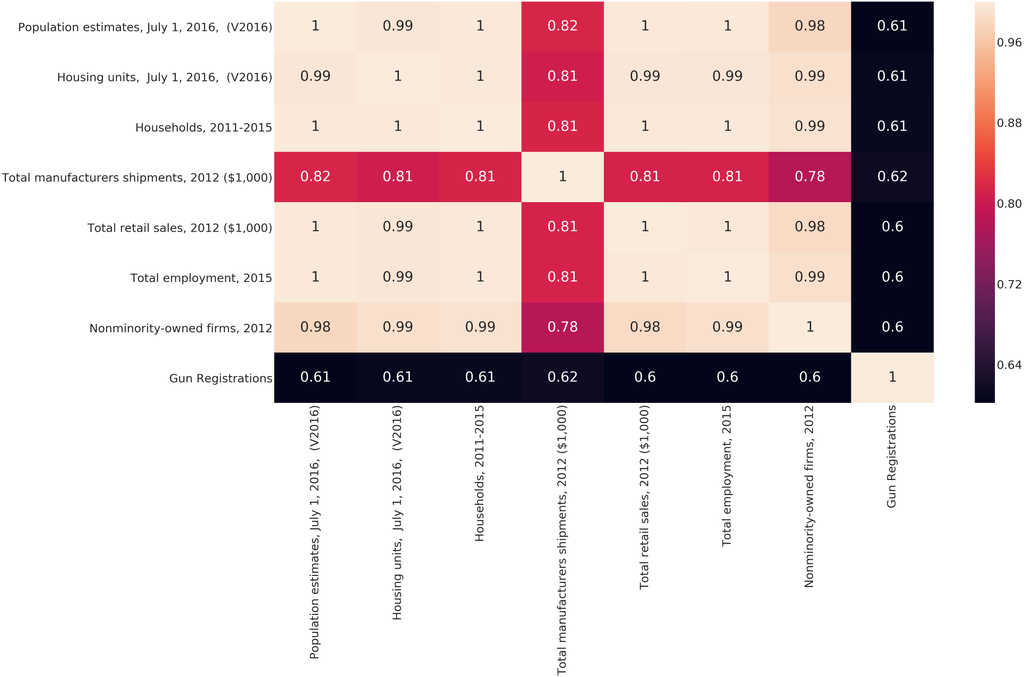

```python
plt.figure(figsize = (64,32))
sns.set(font_scale = 5)
sns.heatmap(corrMatrix_final, annot = True)
plt.show()
```

Before we even dive deper into the analysis we can see the 7 factors that has a med-high correlation to Gun Registration in 2016. This includes:

- Population estimates, July 1, 2016, (V2016)
- Housing units, July 1, 2016, (V2016)
- Households, 2011-2015
- Total manufacturers shipments, 2012 (1,000 USD)
- Total retail sales, 2012 (1,000 USD)
- Total employment, 2015,
- Nonminority-owned firms, 2012

### Research Question 3

#### Which state Per Capita purchased the most guns in 2016

First lest's describe **Per Capita** according to this link from [Indeed](https://www.indeed.com/career-advice/career-development/how-to-calculate-per-capita) Per Capita is described as the following:

> "Calculating per capita entails taking into account a **measurement or number amount** by which you will then divide by the **total population** of the group wishing to be analyzed. The following formula can be used to determine the per capita:"  
> **Per capita = measurement/number of people in a population**

With this in mind I would need to divide gun total per state by total population in the year 2016

Here I create a new dataframe with the 2016 population grouped by State

```python
df_census_16_pop = df_census_clean.reset_index(level = 0).iloc[:,:2]
df_census_16_pop = df_census_16_pop.rename(columns = ({'index':'State',df_census_16_pop.columns[1]:'Estimated 2016 Population'}), index = {'Fact':'index'})

df_census_16_pop.head()
```

| Fact | State | Estimated 2016 Population |
| --- | --- | --- |
| 0 | Alabama | 4863300 |
| 1 | Alaska | 741894 |
| 2 | Arizona | 6931071 |
| 3 | Arkansas | 2988248 |
| 4 | California | 39250017 |

Here I merge the data together so I can calculate **Per Capita**

```python
df_temp_merge = pd.merge(df_gun_16, df_census_16_pop, how = 'inner', left_on = 'state', right_on = 'State')
```

```python
df_temp_merge.head()
```

|  | state | totals | State | Estimated 2016 Population |
| --- | --- | --- | --- | --- |
| 0 | Alabama | 616947 | Alabama | 4863300 |
| 1 | Alaska | 87647 | Alaska | 741894 |
| 2 | Arizona | 416279 | Arizona | 6931071 |
| 3 | Arkansas | 266014 | Arkansas | 2988248 |
| 4 | California | 2377167 | California | 39250017 |

```python
df_temp_merge['gun_per_capita'] = df_temp_merge.totals/df_temp_merge['Estimated 2016 Population']
```

```python
df_temp_merge.head()
```

|  | state | totals | State | Estimated 2016 Population | gun_per_capita |
| --- | --- | --- | --- | --- | --- |
| 0 | Alabama | 616947 | Alabama | 4863300 | 0.126858 |
| 1 | Alaska | 87647 | Alaska | 741894 | 0.118140 |
| 2 | Arizona | 416279 | Arizona | 6931071 | 0.060060 |
| 3 | Arkansas | 266014 | Arkansas | 2988248 | 0.089020 |
| 4 | California | 2377167 | California | 39250017 | 0.060565 |

```python
pdb.output_notebook()
```

```python
df_top_10 = df_temp_merge.nlargest(10,'gun_per_capita')
```

```python
df_top_10.plot_bokeh(kind = 'bar',
                     x = 'state',
                     y = 'gun_per_capita',
                     figsize = (900,500), zooming = False,
                     title = "2016 Top Ten Gun Registration by State",
                    ylabel = 'Guns Per Capita',
                    xlabel = 'States')
```

[interactive chart not shown]

<a id= 'Question_2'></a>

### Research Question 2

#### Which state has seen the most growth in gun registration in the last decade

```python
df_decade_gun_grouped = df_decade_gun.groupby(['state','year'])['state','totals'].agg('sum').reset_index()
df_decade_gun_grouped.loc[:,"yoy"] = df_decade_gun_grouped.totals.pct_change()
df_decade_gun_grouped.head(11)
```

|  | state | year | totals | yoy |
| --- | --- | --- | --- | --- |
| 0 | Alabama | 2007 | 104452 | NaN |
| 1 | Alabama | 2008 | 299432 | 1.866695 |
| 2 | Alabama | 2009 | 317868 | 0.061570 |
| 3 | Alabama | 2010 | 308607 | -0.029135 |
| 4 | Alabama | 2011 | 336102 | 0.089094 |
| 5 | Alabama | 2012 | 431356 | 0.283408 |
| 6 | Alabama | 2013 | 563880 | 0.307227 |
| 7 | Alabama | 2014 | 621305 | 0.101839 |
| 8 | Alabama | 2015 | 737509 | 0.187032 |
| 9 | Alabama | 2016 | 616947 | -0.163472 |
| 10 | Alabama | 2017 | 336763 | -0.454146 |

I'm dropping this row because it gives us an infinite value for the **YoY** value which skews the data

```python
df_decade_gun_grouped.iloc[[235]]
```

|  | state | year | totals | yoy |
| --- | --- | --- | --- | --- |
| 235 | Mariana Islands | 2011 | 1 | inf |

```python
df_decade_gun_grouped.drop(index = 235, inplace = True)
```

Here I group the columns by sum to get the aggeragate each state YoY

```python
df_gun_yoy_growth = df_decade_gun_grouped.groupby(['state'])[['yoy']].sum().reset_index()

df_gun_yoy_growth.head()
```

|  | state | yoy |
| --- | --- | --- |
| 0 | Alabama | 2.250112 |
| 1 | Alaska | 1.403619 |
| 2 | Arizona | 2.838920 |
| 3 | Arkansas | 0.829174 |
| 4 | California | 3.259394 |

Here I graph the top ten results which shows us that Maryland has had the most growth in gun registrations in the last decade

```python
p_xVal = df_gun_yoy_growth.nlargest(10,'yoy').state.tolist()
p_yVal = df_gun_yoy_growth.nlargest(10,'yoy').yoy.tolist()
data = df_gun_yoy_growth.nlargest(10,'yoy')
source = ColumnDataSource(data)
p = figure(plot_width = 700, plot_height = 500, x_range = p_xVal,
          title = "Top 10 State Gun Registration Growth from (2007 - 2017)"
          )
p.vbar( x = 'state', top = 'yoy', width = .5, bottom = 0, color = "#CAB2D6", source = source)
p.xaxis.major_label_orientation = 3.14/4
p.xaxis.axis_label = "States"
p.yaxis.axis_label = "Year over year growth"
p.yaxis.axis_label_text_font_style = "bold"
p.yaxis.axis_label_text_font_size = "16px"
p.yaxis.axis_label_text_font = "times"

hover = HoverTool(tooltips = [("State","@state"), ("YoY", "@yoy")])
p.add_tools(hover)

show(p)
```

[interactive chart not shown]

## Conclusions

### Results

From our three questions and analysis we can conclude the following:

- These Seven Features are most associated with gun registration:
  - Population estimates, July 1, 2016, (V2016)
  - Housing units, July 1, 2016, (V2016)
  - Households, 2011-2015
  - Total manufacturers shipments, 2012 (1,000 USD)
  - Total retail sales, 2012 (1,000 USD)
  - Total employment, 2015,
  - Nonminority-owned firms, 2012
- In 2016 based off the population estimates **Kentucky** had the highest gun registrations per capita
- From 2007 to 2017 **Maryland** had the highest growth in gun registrations.

What can we do with this information?

- If you're in the gun business, this could help you target your gun campaign for the growing markets
- If you're not a fan of guns it can show you what states to be weary to move to if you were to relocate.

There are plenty of other questions that can be answered from this dataset this was just the tip of the iceberg. As I begin to learn more about statistical analysis my conclusions will be more robust.

### Limitations

- This data was based from 2016 estimates so the actual results from 2016 could change the analysis
- Certain columns units were still left as percentages because they were not a percentage of the 2016 population. If this data was available, it could effect our correlation matrix
- When cleaning the **Gun** data set 5830(*46%*) rows were dropped in order to only keep one decade of data. If we were looking at the full data set our results may vary
- The statistical analysis used in this dataset was descriptive and not inferential. Meaning we are only describing relationships and not making any predictions

```python
from subprocess import call
call(['python', '-m', 'nbconvert', 'Investigate_a_Dataset.ipynb'])
```

```
1
```